# Kuan Prelim - Adenoid Cystic Carcinoma

Jason Brant

September 01, 2018

# Summary

## Updates

1. **2017 07 14:**
- Initial analysis

**Note: To hide the code from this document, click the button in the upper right corner.**

# Data

Data including tumors of the head and neck was obtained from the NCBD on March 4, 2016. Cases that were included in this analysis were those with:

1. Site codes: C300, C310, C311, C312, C313, C318, C319
2. Histology codes: 8200
3. Behavior codes: All

Patients were excluded if they didn’t have values for either follow up or vital status.

Patients were excluded if they had surgery to a distant site using `RX_SUMM_SURG_OTH_REGDIS`. This was done to avoid confounding of different surgical procedures. We are only interested in surgery at the primary site. These distant site surgeries were being counted in the surgery/radiation sequence and thus to simplify analysis they were removed.

```
                              level Overall
  n                                 870
  RX_SUMM_SURG_OTH_REGDIS (%) 0     793 (91.1)
                              1       6 ( 0.7)
                              2      45 ( 5.2)
                              3       0 ( 0.0)
                              4       3 ( 0.3)
                              5       0 ( 0.0)
                              9      23 ( 2.6)
```

Whether radiation was performed was based on the `REASON_FOR_NO_RADIATION` variable. The `RADIATION_YN` variable was classified as ‘Yes’, ‘No’, or ‘Unknown’.

```
Unknown levels in `f`: 0Unknown levels in `f`: 4Unknown levels in `f`: 5Unknown levels in `f`: No Tumor, Microscopic focus
```

## Table of variables for all cases:

```
                                          level                         Overall
  n                                                                       793
  FACILITY_TYPE_F (%)                     Community Cancer Program         36 (  4.5)
                                          Comprehensive Comm Ca Program   187 ( 23.6)
                                          Academic/Research Program       439 ( 55.4)
                                          Integrated Network Ca Program    60 (  7.6)
                                          Other                             2 (  0.3)
                                          <NA>                             69 (  8.7)
  FACILITY_LOCATION_F (%)                 New England                      28 (  3.5)
                                          Middle Atlantic                 104 ( 13.1)
                                          South Atlantic                  163 ( 20.6)
                                          East North Central              137 ( 17.3)
                                          East South Central               43 (  5.4)
                                          West North Central               57 (  7.2)
                                          West South Central               41 (  5.2)
                                          Mountain                         42 (  5.3)
                                          Pacific                         109 ( 13.7)
                                          <NA>                             69 (  8.7)
  FACILITY_GEOGRAPHY (%)                  Northeast                       132 ( 16.6)
                                          South                           204 ( 25.7)
                                          Midwest                         237 ( 29.9)
                                          West                            151 ( 19.0)
                                          <NA>                             69 (  8.7)
  AGE (mean (sd))                                                       59.63 (14.42)
  AGE_F (%)                               (0,54]                          296 ( 37.3)
                                          (54,64]                         189 ( 23.8)
                                          (64,74]                         163 ( 20.6)
                                          (74,100]                        145 ( 18.3)
  SEX_F (%)                               Male                            372 ( 46.9)
                                          Female                          421 ( 53.1)
  RACE_F (%)                              White                           628 ( 79.2)
                                          Black                           104 ( 13.1)
                                          Other/Unk                        24 (  3.0)
                                          Asian                            37 (  4.7)
  HISPANIC (%)                            No                              673 ( 84.9)
                                          Yes                              58 (  7.3)
                                          Unknown                          62 (  7.8)
  INSURANCE_F (%)                         Private                         392 ( 49.4)
                                          None                             36 (  4.5)
                                          Medicaid                         64 (  8.1)
```

[output cut: 175 more lines]

```
                                          2-3 cm                           82 ( 10.3)
                                          3-4 cm                           77 (  9.7)
                                          4-5 cm                          101 ( 12.7)
                                          5-6 cm                           52 (  6.6)
                                          >6 cm                            74 (  9.3)
                                          NA_unk                          362 ( 45.6)
  SURGERY_YN (%)                          No                              163 ( 20.6)
                                          Ukn                              11 (  1.4)
                                          Yes                             619 ( 78.1)
  RADIATION_YN (%)                        No                              244 ( 30.8)
                                          Ukn                               7 (  0.9)
                                          Yes                             542 ( 68.3)
  CHEMO_YN (%)                            No                              628 ( 79.2)
                                          Yes                             124 ( 15.6)
                                          Ukn                              41 (  5.2)
```

## Added endoscopic levels

```
           level              Overall
  n                           793
  ENDO (%) Endoscopic          59 ( 7.4)
           Endoscopic to Open   5 ( 0.6)
           No surgery          84 (10.6)
           Open or Unknown    119 (15.0)
           Unknown              1 ( 0.1)
           <NA>               525 (66.2)
```

# Kaplan Meier Analysis

## All

```
_________________________________________________

## All
_________________________________________________
Call: survfit(formula = Surv(DX_LASTCONTACT_DEATH_MONTHS, PUF_VITAL_STATUS ==
    0) ~ All, data = data)

      n  events  median 0.95LCL 0.95UCL
  793.0   310.0    78.5    72.0    88.0

Call: survfit(formula = Surv(DX_LASTCONTACT_DEATH_MONTHS, PUF_VITAL_STATUS ==
    0) ~ All, data = data)

 time n.risk n.event survival std.err lower 95% CI upper 95% CI
   12    678      71    0.907  0.0105        0.887        0.928
   24    568      54    0.832  0.0137        0.806        0.860
   36    427      54    0.747  0.0165        0.715        0.780
   48    332      37    0.678  0.0185        0.642        0.715
   60    243      32    0.607  0.0204        0.568        0.648
  120      7      62    0.281  0.0486        0.200        0.394




## Univariable Cox Proportional Hazard Model for:  All

[1] "Only one level, no Cox model performed"





## Unadjusted Kaplan Meier Overall Survival Curve for:  All
```

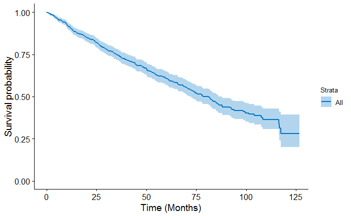

## Facility Type

```
_________________________________________________

## FACILITY_TYPE_F
_________________________________________________
Call: survfit(formula = Surv(DX_LASTCONTACT_DEATH_MONTHS, PUF_VITAL_STATUS ==
    0) ~ FACILITY_TYPE_F, data = data)

   69 observations deleted due to missingness
                                                n events median 0.95LCL 0.95UCL
FACILITY_TYPE_F=Community Cancer Program       36     20   54.8    29.4      NA
FACILITY_TYPE_F=Comprehensive Comm Ca Program 187     77   72.7    61.3      NA
FACILITY_TYPE_F=Academic/Research Program     439    175   75.6    69.5    84.8
FACILITY_TYPE_F=Integrated Network Ca Program  60     23   65.7    56.0      NA
FACILITY_TYPE_F=Other                           2      0     NA      NA      NA

Call: survfit(formula = Surv(DX_LASTCONTACT_DEATH_MONTHS, PUF_VITAL_STATUS ==
    0) ~ FACILITY_TYPE_F, data = data)

69 observations deleted due to missingness
                FACILITY_TYPE_F=Community Cancer Program
 time n.risk n.event survival std.err lower 95% CI upper 95% CI
   12     28       5    0.852  0.0613        0.739        0.981
   24     23       4    0.728  0.0777        0.590        0.897
   36     16       4    0.593  0.0877        0.444        0.793
   48     13       2    0.519  0.0911        0.368        0.732
   60      8       2    0.433  0.0943        0.282        0.663

                FACILITY_TYPE_F=Comprehensive Comm Ca Program
 time n.risk n.event survival std.err lower 95% CI upper 95% CI
   12    158      23    0.874  0.0245        0.827        0.924
   24    136       9    0.822  0.0285        0.768        0.880
   36     97      15    0.724  0.0347        0.659        0.795
   48     78      13    0.624  0.0394        0.552        0.707
   60     63       3    0.596  0.0409        0.521        0.682

                FACILITY_TYPE_F=Academic/Research Program
 time n.risk n.event survival std.err lower 95% CI upper 95% CI
   12    379      37    0.913  0.0137        0.887        0.940
   24    311      32    0.833  0.0184        0.797        0.870
   36    233      29    0.748  0.0224        0.705        0.793
```

[output cut: 10 more lines]

```
   60     18       5    0.572  0.0753        0.442        0.740

                FACILITY_TYPE_F=Other
 time n.risk n.event survival std.err lower 95% CI upper 95% CI
   12      2       0        1       0            1            1
   24      2       0        1       0            1            1
   36      1       0        1       0            1            1
   48      1       0        1       0            1            1
   60      1       0        1       0            1            1





## Univariable Cox Proportional Hazard Model for:  FACILITY_TYPE_F
```

```
Loglik converged before variable  4 ; beta may be infinite.
```

```
Call:
coxph(formula = Surv(DX_LASTCONTACT_DEATH_MONTHS, PUF_VITAL_STATUS ==
    0) ~ FACILITY_TYPE_F, data = data)

  n= 724, number of events= 295
   (69 observations deleted due to missingness)

                                                   coef  exp(coef)   se(coef)      z Pr(>|z|)
FACILITY_TYPE_FComprehensive Comm Ca Program -4.980e-01  6.077e-01  2.514e-01 -1.981   0.0476 *
FACILITY_TYPE_FAcademic/Research Program     -5.044e-01  6.038e-01  2.365e-01 -2.133   0.0329 *
FACILITY_TYPE_FIntegrated Network Ca Program -5.595e-01  5.715e-01  3.060e-01 -1.828   0.0675 .
FACILITY_TYPE_FOther                         -1.450e+01  5.063e-07  1.127e+03 -0.013   0.9897
---
Signif. codes:  0 *** 0.001 ** 0.01 * 0.05 . 0.1   1

                                             exp(coef) exp(-coef) lower .95 upper .95
FACILITY_TYPE_FComprehensive Comm Ca Program 6.077e-01  1.645e+00    0.3713    0.9946
FACILITY_TYPE_FAcademic/Research Program     6.038e-01  1.656e+00    0.3799    0.9599
FACILITY_TYPE_FIntegrated Network Ca Program 5.715e-01  1.750e+00    0.3137    1.0411
FACILITY_TYPE_FOther                         5.063e-07  1.975e+06    0.0000       Inf

Concordance= 0.526  (se = 0.016 )
Rsquare= 0.008   (max possible= 0.992 )
Likelihood ratio test= 6.14  on 4 df,   p=0.2
Wald test            = 4.85  on 4 df,   p=0.3
Score (logrank) test = 5.94  on 4 df,   p=0.2
```

[output not shown]

```
## Unadjusted Kaplan Meier Overall Survival Curve for:  FACILITY_TYPE_F
```

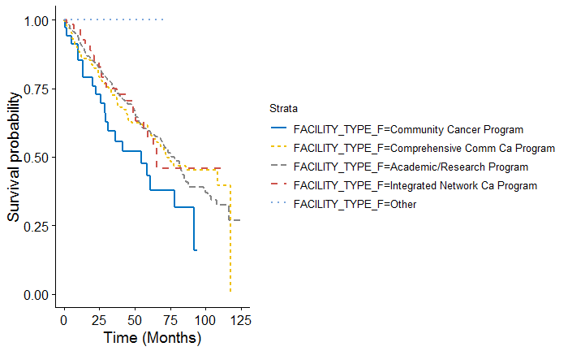

## Facility Location

```
_________________________________________________

## FACILITY_LOCATION_F
_________________________________________________
Call: survfit(formula = Surv(DX_LASTCONTACT_DEATH_MONTHS, PUF_VITAL_STATUS ==
    0) ~ FACILITY_LOCATION_F, data = data)

   69 observations deleted due to missingness
                                         n events median 0.95LCL 0.95UCL
FACILITY_LOCATION_F=New England         28     14   52.8    44.4      NA
FACILITY_LOCATION_F=Middle Atlantic    104     36   75.6    69.5      NA
FACILITY_LOCATION_F=South Atlantic     163     78   61.3    48.8    75.1
FACILITY_LOCATION_F=East North Central 137     51   84.8    63.1      NA
FACILITY_LOCATION_F=East South Central  43     19   72.3    50.3      NA
FACILITY_LOCATION_F=West North Central  57     24   70.8    49.0      NA
FACILITY_LOCATION_F=West South Central  41     13     NA    77.9      NA
FACILITY_LOCATION_F=Mountain            42     14   83.6    72.0      NA
FACILITY_LOCATION_F=Pacific            109     46   71.0    59.4      NA

Call: survfit(formula = Surv(DX_LASTCONTACT_DEATH_MONTHS, PUF_VITAL_STATUS ==
    0) ~ FACILITY_LOCATION_F, data = data)

69 observations deleted due to missingness
                FACILITY_LOCATION_F=New England
 time n.risk n.event survival std.err lower 95% CI upper 95% CI
   12     22       4    0.849  0.0699        0.722        0.997
   24     21       0    0.849  0.0699        0.722        0.997
   36     18       2    0.766  0.0842        0.617        0.950
   48     13       5    0.553  0.1011        0.386        0.791
   60      8       3    0.415  0.1026        0.255        0.674
  120      1       0    0.415  0.1026        0.255        0.674

                FACILITY_LOCATION_F=Middle Atlantic
 time n.risk n.event survival std.err lower 95% CI upper 95% CI
   12     88       5    0.948  0.0227        0.904        0.993
   24     73       9    0.848  0.0375        0.777        0.925
   36     48       8    0.741  0.0483        0.653        0.842
   48     38       2    0.709  0.0514        0.615        0.817
   60     28       1    0.690  0.0534        0.593        0.803

```

[output cut: 83 more lines]

```
                                      exp(coef) exp(-coef) lower .95 upper .95
FACILITY_LOCATION_FMiddle Atlantic       0.7848     1.2743    0.4231     1.456
FACILITY_LOCATION_FSouth Atlantic        1.0587     0.9445    0.5991     1.871
FACILITY_LOCATION_FEast North Central    0.7812     1.2800    0.4322     1.412
FACILITY_LOCATION_FEast South Central    0.9349     1.0697    0.4684     1.866
FACILITY_LOCATION_FWest North Central    0.8109     1.2332    0.4193     1.568
FACILITY_LOCATION_FWest South Central    0.6519     1.5341    0.3063     1.387
FACILITY_LOCATION_FMountain              0.6335     1.5786    0.3018     1.330
FACILITY_LOCATION_FPacific               0.9080     1.1013    0.4990     1.652

Concordance= 0.545  (se = 0.018 )
Rsquare= 0.01   (max possible= 0.992 )
Likelihood ratio test= 7.13  on 8 df,   p=0.5
Wald test            = 7.02  on 8 df,   p=0.5
Score (logrank) test = 7.1  on 8 df,   p=0.5
```

```
Removed 1 rows containing missing values (geom_errorbar).
```

```
## Unadjusted Kaplan Meier Overall Survival Curve for:  FACILITY_LOCATION_F
```

## Facility Geography

```
_________________________________________________

## FACILITY_GEOGRAPHY
_________________________________________________
Call: survfit(formula = Surv(DX_LASTCONTACT_DEATH_MONTHS, PUF_VITAL_STATUS ==
    0) ~ FACILITY_GEOGRAPHY, data = data)

   69 observations deleted due to missingness
                               n events median 0.95LCL 0.95UCL
FACILITY_GEOGRAPHY=Northeast 132     50   73.2    61.7      NA
FACILITY_GEOGRAPHY=South     204     91   65.7    54.1    82.2
FACILITY_GEOGRAPHY=Midwest   237     94   78.1    63.1   108.5
FACILITY_GEOGRAPHY=West      151     60   82.1    68.3      NA

Call: survfit(formula = Surv(DX_LASTCONTACT_DEATH_MONTHS, PUF_VITAL_STATUS ==
    0) ~ FACILITY_GEOGRAPHY, data = data)

69 observations deleted due to missingness
                FACILITY_GEOGRAPHY=Northeast
 time n.risk n.event survival std.err lower 95% CI upper 95% CI
   12    110       9    0.926  0.0237       0.8811        0.974
   24     94       9    0.849  0.0329       0.7866        0.916
   36     66      10    0.748  0.0419       0.6699        0.834
   48     51       7    0.663  0.0479       0.5755        0.764
   60     36       4    0.605  0.0518       0.5113        0.715
  120      1      11    0.123  0.1030       0.0237        0.636

                FACILITY_GEOGRAPHY=South
 time n.risk n.event survival std.err lower 95% CI upper 95% CI
   12    172      22    0.889  0.0224        0.846        0.934
   24    146      14    0.815  0.0279        0.762        0.872
   36    104      20    0.696  0.0343        0.632        0.767
   48     78      11    0.616  0.0379        0.546        0.695
   60     57       9    0.541  0.0408        0.466        0.627
  120      1      15    0.369  0.0471        0.287        0.474

                FACILITY_GEOGRAPHY=Midwest
 time n.risk n.event survival std.err lower 95% CI upper 95% CI
   12    211      19    0.918  0.0180        0.883        0.954
   24    171      21    0.821  0.0257        0.773        0.873
```

[output cut: 27 more lines]

```
                              coef exp(coef) se(coef)      z Pr(>|z|)
FACILITY_GEOGRAPHYSouth    0.15198   1.16414  0.17617  0.863    0.388
FACILITY_GEOGRAPHYMidwest -0.02312   0.97715  0.17516 -0.132    0.895
FACILITY_GEOGRAPHYWest    -0.01228   0.98779  0.19165 -0.064    0.949

                          exp(coef) exp(-coef) lower .95 upper .95
FACILITY_GEOGRAPHYSouth      1.1641      0.859    0.8242     1.644
FACILITY_GEOGRAPHYMidwest    0.9771      1.023    0.6932     1.377
FACILITY_GEOGRAPHYWest       0.9878      1.012    0.6785     1.438

Concordance= 0.519  (se = 0.018 )
Rsquare= 0.002   (max possible= 0.992 )
Likelihood ratio test= 1.72  on 3 df,   p=0.6
Wald test            = 1.75  on 3 df,   p=0.6
Score (logrank) test = 1.76  on 3 df,   p=0.6
```

```
Removed 1 rows containing missing values (geom_errorbar).
```

```
## Unadjusted Kaplan Meier Overall Survival Curve for:  FACILITY_GEOGRAPHY
```

## Age Group

```
_________________________________________________

## AGE_F
_________________________________________________
Call: survfit(formula = Surv(DX_LASTCONTACT_DEATH_MONTHS, PUF_VITAL_STATUS ==
    0) ~ AGE_F, data = data)

                 n events median 0.95LCL 0.95UCL
AGE_F=(0,54]   296     85  101.5    88.0      NA
AGE_F=(54,64]  189     72   78.5    65.7      NA
AGE_F=(64,74]  163     67   83.1    70.8     117
AGE_F=(74,100] 145     86   47.9    37.2      56

Call: survfit(formula = Surv(DX_LASTCONTACT_DEATH_MONTHS, PUF_VITAL_STATUS ==
    0) ~ AGE_F, data = data)

                AGE_F=(0,54]
 time n.risk n.event survival std.err lower 95% CI upper 95% CI
   12    258      15    0.946  0.0136        0.920        0.973
   24    223      14    0.893  0.0189        0.856        0.930
   36    168      16    0.824  0.0240        0.778        0.872
   48    134      10    0.771  0.0277        0.718        0.827
   60    106       7    0.728  0.0306        0.670        0.790
  120      3      23    0.465  0.0534        0.371        0.582

                AGE_F=(54,64]
 time n.risk n.event survival std.err lower 95% CI upper 95% CI
   12    166      15    0.919  0.0200        0.881        0.959
   24    134      17    0.821  0.0288        0.766        0.879
   36     99      12    0.741  0.0341        0.677        0.811
   48     76      10    0.663  0.0383        0.592        0.743
   60     50       7    0.592  0.0427        0.514        0.682
  120      1      11    0.333  0.0787        0.210        0.529

                AGE_F=(64,74]
 time n.risk n.event survival std.err lower 95% CI upper 95% CI
   12    137      17    0.892  0.0248       0.8446        0.942
   24    117      10    0.825  0.0306       0.7671        0.887
   36     97       8    0.765  0.0350       0.6994        0.837
   48     75       8    0.696  0.0395       0.6225        0.778
```

[output cut: 25 more lines]

```
AGE_F(64,74]  0.3323    1.3942   0.1635 2.032   0.0422 *
AGE_F(74,100] 1.0436    2.8395   0.1542 6.768 1.31e-11 ***
---
Signif. codes:  0 *** 0.001 ** 0.01 * 0.05 . 0.1   1

              exp(coef) exp(-coef) lower .95 upper .95
AGE_F(54,64]      1.489     0.6716     1.087     2.039
AGE_F(64,74]      1.394     0.7173     1.012     1.921
AGE_F(74,100]     2.840     0.3522     2.099     3.841

Concordance= 0.6  (se = 0.017 )
Rsquare= 0.054   (max possible= 0.991 )
Likelihood ratio test= 44.23  on 3 df,   p=1e-09
Wald test            = 47.68  on 3 df,   p=2e-10
Score (logrank) test = 50.71  on 3 df,   p=6e-11
```

```
Removed 1 rows containing missing values (geom_errorbar).
```

```
## Unadjusted Kaplan Meier Overall Survival Curve for:  AGE_F
```

## Gender

```
_________________________________________________

## SEX_F
_________________________________________________
Call: survfit(formula = Surv(DX_LASTCONTACT_DEATH_MONTHS, PUF_VITAL_STATUS ==
    0) ~ SEX_F, data = data)

               n events median 0.95LCL 0.95UCL
SEX_F=Male   372    139   77.5    68.8    92.7
SEX_F=Female 421    171   81.2    70.8    94.2

Call: survfit(formula = Surv(DX_LASTCONTACT_DEATH_MONTHS, PUF_VITAL_STATUS ==
    0) ~ SEX_F, data = data)

                SEX_F=Male
 time n.risk n.event survival std.err lower 95% CI upper 95% CI
   12    316      31    0.913  0.0150        0.884        0.943
   24    263      24    0.840  0.0198        0.802        0.880
   36    208      20    0.772  0.0233        0.728        0.819
   48    150      23    0.681  0.0273        0.630        0.737
   60    102      17    0.596  0.0307        0.539        0.660
  120      4      24    0.297  0.0642        0.195        0.454

                SEX_F=Female
 time n.risk n.event survival std.err lower 95% CI upper 95% CI
   12    362      40    0.902  0.0147        0.874        0.931
   24    305      30    0.825  0.0190        0.789        0.863
   36    219      34    0.725  0.0232        0.681        0.772
   48    182      14    0.675  0.0252        0.628        0.726
   60    141      15    0.616  0.0273        0.564        0.671
  120      3      38    0.257  0.0747        0.145        0.454





## Univariable Cox Proportional Hazard Model for:  SEX_F

Call:
coxph(formula = Surv(DX_LASTCONTACT_DEATH_MONTHS, PUF_VITAL_STATUS ==
    0) ~ SEX_F, data = data)

  n= 793, number of events= 310

               coef exp(coef) se(coef)     z Pr(>|z|)
SEX_FFemale 0.01988   1.02008  0.11438 0.174    0.862

            exp(coef) exp(-coef) lower .95 upper .95
SEX_FFemale      1.02     0.9803    0.8152     1.276

Concordance= 0.507  (se = 0.016 )
Rsquare= 0   (max possible= 0.991 )
Likelihood ratio test= 0.03  on 1 df,   p=0.9
Wald test            = 0.03  on 1 df,   p=0.9
Score (logrank) test = 0.03  on 1 df,   p=0.9
```

```
Removed 1 rows containing missing values (geom_errorbar).
```

```
## Unadjusted Kaplan Meier Overall Survival Curve for:  SEX_F
```

## RACE_F

```
_________________________________________________

## RACE_F
_________________________________________________
Call: survfit(formula = Surv(DX_LASTCONTACT_DEATH_MONTHS, PUF_VITAL_STATUS ==
    0) ~ RACE_F, data = data)

                   n events median 0.95LCL 0.95UCL
RACE_F=White     628    247   77.9    70.8    91.9
RACE_F=Black     104     46   70.4    61.1    85.5
RACE_F=Other/Unk  24      8   86.2    52.2      NA
RACE_F=Asian      37      9  116.6   101.5      NA

Call: survfit(formula = Surv(DX_LASTCONTACT_DEATH_MONTHS, PUF_VITAL_STATUS ==
    0) ~ RACE_F, data = data)

                RACE_F=White
 time n.risk n.event survival std.err lower 95% CI upper 95% CI
   12    538      54    0.911  0.0116        0.888        0.934
   24    440      47    0.828  0.0156        0.798        0.859
   36    334      43    0.740  0.0188        0.704        0.778
   48    260      31    0.668  0.0211        0.627        0.710
   60    190      26    0.595  0.0231        0.551        0.642
  120      5      46    0.295  0.0560        0.203        0.428

                RACE_F=Black
 time n.risk n.event survival std.err lower 95% CI upper 95% CI
   12     85      14    0.861  0.0345        0.796        0.931
   24     79       4    0.820  0.0385        0.748        0.899
   36     55       8    0.733  0.0450        0.650        0.827
   48     39       5    0.655  0.0522        0.560        0.766
   60     28       2    0.619  0.0552        0.520        0.737

                RACE_F=Other/Unk
 time n.risk n.event survival std.err lower 95% CI upper 95% CI
   12     21       1    0.957  0.0425        0.877        1.000
   24     18       2    0.865  0.0723        0.735        1.000
   36     14       2    0.763  0.0935        0.600        0.970
   48     12       1    0.704  0.1031        0.529        0.938
   60     10       1    0.645  0.1099        0.462        0.901
```

[output cut: 25 more lines]

```
RACE_FOther/Unk -0.3218    0.7248   0.3596 -0.895   0.3708
RACE_FAsian     -0.6344    0.5302   0.3396 -1.868   0.0617 .
---
Signif. codes:  0 *** 0.001 ** 0.01 * 0.05 . 0.1   1

                exp(coef) exp(-coef) lower .95 upper .95
RACE_FBlack        1.2443     0.8036    0.9074     1.706
RACE_FOther/Unk    0.7248     1.3797    0.3582     1.467
RACE_FAsian        0.5302     1.8859    0.2725     1.032

Concordance= 0.526  (se = 0.013 )
Rsquare= 0.009   (max possible= 0.991 )
Likelihood ratio test= 7.45  on 3 df,   p=0.06
Wald test            = 6.6  on 3 df,   p=0.09
Score (logrank) test = 6.78  on 3 df,   p=0.08
```

```
Removed 1 rows containing missing values (geom_errorbar).
```

```
## Unadjusted Kaplan Meier Overall Survival Curve for:  RACE_F
```

## Hispanic

```
_________________________________________________

## HISPANIC
_________________________________________________
Call: survfit(formula = Surv(DX_LASTCONTACT_DEATH_MONTHS, PUF_VITAL_STATUS ==
    0) ~ HISPANIC, data = data)

                   n events median 0.95LCL 0.95UCL
HISPANIC=No      673    274   75.6    68.8      85
HISPANIC=Yes      58     10     NA      NA      NA
HISPANIC=Unknown  62     26   82.8    60.6      NA

Call: survfit(formula = Surv(DX_LASTCONTACT_DEATH_MONTHS, PUF_VITAL_STATUS ==
    0) ~ HISPANIC, data = data)

                HISPANIC=No
 time n.risk n.event survival std.err lower 95% CI upper 95% CI
   12    574      63    0.903  0.0116        0.881        0.926
   24    477      49    0.823  0.0152        0.794        0.853
   36    357      46    0.737  0.0181        0.703        0.774
   48    279      33    0.665  0.0203        0.626        0.706
   60    199      29    0.589  0.0224        0.547        0.635
  120      6      54    0.249  0.0504        0.167        0.370

                HISPANIC=Yes
 time n.risk n.event survival std.err lower 95% CI upper 95% CI
   12     49       3    0.947  0.0300        0.890        1.000
   24     42       1    0.927  0.0355        0.860        0.999
   36     31       3    0.855  0.0515        0.760        0.962
   48     22       1    0.827  0.0567        0.723        0.946
   60     19       1    0.790  0.0654        0.671        0.929

                HISPANIC=Unknown
 time n.risk n.event survival std.err lower 95% CI upper 95% CI
   12     55       5    0.917  0.0357        0.849        0.989
   24     49       4    0.849  0.0465        0.762        0.945
   36     39       5    0.757  0.0567        0.654        0.877
   48     31       3    0.698  0.0619        0.586        0.830
   60     25       2    0.648  0.0667        0.529        0.793
  120      1       7    0.322  0.1141        0.161        0.645
```

[output cut: 13 more lines]

```
                    coef exp(coef) se(coef)      z Pr(>|z|)
HISPANICYes     -0.91690   0.39976  0.32211 -2.847  0.00442 **
HISPANICUnknown -0.09584   0.90861  0.20530 -0.467  0.64062
---
Signif. codes:  0 *** 0.001 ** 0.01 * 0.05 . 0.1   1

                exp(coef) exp(-coef) lower .95 upper .95
HISPANICYes        0.3998      2.502    0.2126    0.7516
HISPANICUnknown    0.9086      1.101    0.6076    1.3587

Concordance= 0.523  (se = 0.011 )
Rsquare= 0.014   (max possible= 0.991 )
Likelihood ratio test= 10.95  on 2 df,   p=0.004
Wald test            = 8.2  on 2 df,   p=0.02
Score (logrank) test = 8.77  on 2 df,   p=0.01
```

```
Removed 1 rows containing missing values (geom_errorbar).
```

```
## Unadjusted Kaplan Meier Overall Survival Curve for:  HISPANIC
```

## Insurance Status

```
_________________________________________________

## INSURANCE_F
_________________________________________________
Call: survfit(formula = Surv(DX_LASTCONTACT_DEATH_MONTHS, PUF_VITAL_STATUS ==
    0) ~ INSURANCE_F, data = data)

                               n events median 0.95LCL 0.95UCL
INSURANCE_F=Private          392    121   99.7    85.5      NA
INSURANCE_F=None              36     17   64.2    44.4      NA
INSURANCE_F=Medicaid          64     27   61.3    45.2      NA
INSURANCE_F=Medicare         275    138   60.6    51.1    72.7
INSURANCE_F=Other Government   9      2     NA    88.0      NA
INSURANCE_F=Unknown           17      5     NA    49.0      NA

Call: survfit(formula = Surv(DX_LASTCONTACT_DEATH_MONTHS, PUF_VITAL_STATUS ==
    0) ~ INSURANCE_F, data = data)

                INSURANCE_F=Private
 time n.risk n.event survival std.err lower 95% CI upper 95% CI
   12    345      22    0.941  0.0122        0.918        0.965
   24    292      23    0.876  0.0174        0.842        0.910
   36    219      26    0.790  0.0224        0.748        0.835
   48    176      13    0.741  0.0248        0.694        0.792
   60    130      13    0.681  0.0279        0.628        0.738
  120      3      24    0.455  0.0477        0.370        0.559

                INSURANCE_F=None
 time n.risk n.event survival std.err lower 95% CI upper 95% CI
   12     28       6    0.825  0.0649        0.707        0.963
   24     23       3    0.737  0.0754        0.603        0.900
   36     19       2    0.671  0.0817        0.529        0.852
   48     16       1    0.632  0.0859        0.484        0.825
   60     11       1    0.592  0.0892        0.441        0.795

                INSURANCE_F=Medicaid
 time n.risk n.event survival std.err lower 95% CI upper 95% CI
   12     51       5    0.915  0.0366        0.845        0.989
   24     44       3    0.860  0.0462        0.774        0.955
   36     32       5    0.753  0.0602        0.644        0.881
```

[output cut: 46 more lines]

```
---
Signif. codes:  0 *** 0.001 ** 0.01 * 0.05 . 0.1   1

                            exp(coef) exp(-coef) lower .95 upper .95
INSURANCE_FNone                1.7339     0.5767    1.0433     2.882
INSURANCE_FMedicaid            1.7708     0.5647    1.1655     2.690
INSURANCE_FMedicare            1.8147     0.5510    1.4212     2.317
INSURANCE_FOther Government    0.7212     1.3866    0.1782     2.918
INSURANCE_FUnknown             0.8107     1.2336    0.3313     1.983

Concordance= 0.581  (se = 0.017 )
Rsquare= 0.035   (max possible= 0.991 )
Likelihood ratio test= 28.26  on 5 df,   p=3e-05
Wald test            = 27.52  on 5 df,   p=5e-05
Score (logrank) test = 28.4  on 5 df,   p=3e-05
```

```
Removed 1 rows containing missing values (geom_errorbar).
```

```
## Unadjusted Kaplan Meier Overall Survival Curve for:  INSURANCE_F
```

## Income

```
_________________________________________________

## INCOME_F
_________________________________________________
Call: survfit(formula = Surv(DX_LASTCONTACT_DEATH_MONTHS, PUF_VITAL_STATUS ==
    0) ~ INCOME_F, data = data)

   16 observations deleted due to missingness
                             n events median 0.95LCL 0.95UCL
INCOME_F=Less than $38,000 144     64   72.7    52.2    94.2
INCOME_F=$38,000 - $47,999 171     69   70.4    60.6      NA
INCOME_F=$48,000 - $62,999 204     83   74.3    61.3   104.1
INCOME_F=$63,000 +         258     82   88.0    78.1      NA

Call: survfit(formula = Surv(DX_LASTCONTACT_DEATH_MONTHS, PUF_VITAL_STATUS ==
    0) ~ INCOME_F, data = data)

16 observations deleted due to missingness
                INCOME_F=Less than $38,000
 time n.risk n.event survival std.err lower 95% CI upper 95% CI
   12    121      16    0.884  0.0272        0.833        0.939
   24    100      13    0.787  0.0352        0.720        0.859
   36     72      12    0.688  0.0407        0.613        0.773
   48     54       9    0.594  0.0458        0.510        0.690
   60     42       3    0.558  0.0474        0.472        0.659
  120      2      11    0.352  0.0589        0.254        0.489

                INCOME_F=$38,000 - $47,999
 time n.risk n.event survival std.err lower 95% CI upper 95% CI
   12    150      11    0.932  0.0197        0.895        0.972
   24    118      16    0.828  0.0302        0.771        0.889
   36     86      14    0.722  0.0373        0.653        0.799
   48     69       7    0.659  0.0411        0.583        0.745
   60     56       7    0.588  0.0446        0.507        0.682
  120      1      14    0.257  0.1135        0.108        0.611

                INCOME_F=$48,000 - $62,999
 time n.risk n.event survival std.err lower 95% CI upper 95% CI
   12    166      23    0.883  0.0229        0.839        0.929
   24    140      12    0.818  0.0279        0.765        0.874
```

[output cut: 28 more lines]

```
INCOME_F$48,000 - $62,999 -0.06751   0.93471  0.16647 -0.406   0.6851
INCOME_F$63,000 +         -0.41677   0.65917  0.16687 -2.498   0.0125 *
---
Signif. codes:  0 *** 0.001 ** 0.01 * 0.05 . 0.1   1

                          exp(coef) exp(-coef) lower .95 upper .95
INCOME_F$38,000 - $47,999    0.8986      1.113    0.6393    1.2631
INCOME_F$48,000 - $62,999    0.9347      1.070    0.6745    1.2953
INCOME_F$63,000 +            0.6592      1.517    0.4753    0.9142

Concordance= 0.553  (se = 0.018 )
Rsquare= 0.011   (max possible= 0.99 )
Likelihood ratio test= 8.28  on 3 df,   p=0.04
Wald test            = 7.94  on 3 df,   p=0.05
Score (logrank) test = 8.03  on 3 df,   p=0.05
```

```
Removed 1 rows containing missing values (geom_errorbar).
```

```
## Unadjusted Kaplan Meier Overall Survival Curve for:  INCOME_F
```

## Education

```
_________________________________________________

## EDUCATION_F
_________________________________________________
Call: survfit(formula = Surv(DX_LASTCONTACT_DEATH_MONTHS, PUF_VITAL_STATUS ==
    0) ~ EDUCATION_F, data = data)

   15 observations deleted due to missingness
                           n events median 0.95LCL 0.95UCL
EDUCATION_F=21% or more  133     53   77.9    47.7      NA
EDUCATION_F=13 - 20.9%   210     79   75.6    68.8      NA
EDUCATION_F=7 - 12.9%    246    104   72.0    63.1    86.2
EDUCATION_F=Less than 7% 189     62   88.0    82.8      NA

Call: survfit(formula = Surv(DX_LASTCONTACT_DEATH_MONTHS, PUF_VITAL_STATUS ==
    0) ~ EDUCATION_F, data = data)

15 observations deleted due to missingness
                EDUCATION_F=21% or more
 time n.risk n.event survival std.err lower 95% CI upper 95% CI
   12    114      10    0.921  0.0241        0.875        0.969
   24     93      12    0.819  0.0350        0.753        0.891
   36     64      15    0.677  0.0442        0.596        0.770
   48     47       8    0.584  0.0489        0.496        0.689
   60     34       2    0.555  0.0508        0.464        0.664
  120      1       6    0.405  0.0655        0.295        0.556

                EDUCATION_F=13 - 20.9%
 time n.risk n.event survival std.err lower 95% CI upper 95% CI
   12    180      20    0.902  0.0209        0.862        0.944
   24    151      14    0.829  0.0268        0.778        0.883
   36    106      15    0.737  0.0327        0.676        0.804
   48     82       8    0.677  0.0363        0.610        0.752
   60     62       8    0.607  0.0402        0.533        0.691
  120      2      14    0.356  0.0673        0.246        0.516

                EDUCATION_F=7 - 12.9%
 time n.risk n.event survival std.err lower 95% CI upper 95% CI
   12    211      23   0.9039  0.0191       0.8673        0.942
   24    178      14   0.8420  0.0239       0.7965        0.890
```

[output cut: 29 more lines]

```
EDUCATION_F7 - 12.9%    -0.001635  0.998366  0.168918 -0.010   0.9923
EDUCATION_FLess than 7% -0.360755  0.697150  0.187314 -1.926   0.0541 .
---
Signif. codes:  0 *** 0.001 ** 0.01 * 0.05 . 0.1   1

                        exp(coef) exp(-coef) lower .95 upper .95
EDUCATION_F13 - 20.9%      0.9033      1.107    0.6377     1.279
EDUCATION_F7 - 12.9%       0.9984      1.002    0.7170     1.390
EDUCATION_FLess than 7%    0.6972      1.434    0.4829     1.006

Concordance= 0.532  (se = 0.018 )
Rsquare= 0.008   (max possible= 0.99 )
Likelihood ratio test= 6.02  on 3 df,   p=0.1
Wald test            = 5.73  on 3 df,   p=0.1
Score (logrank) test = 5.78  on 3 df,   p=0.1
```

```
Removed 1 rows containing missing values (geom_errorbar).
```

```
## Unadjusted Kaplan Meier Overall Survival Curve for:  EDUCATION_F
```

## Urban/Rural

```
_________________________________________________

## U_R_F
_________________________________________________
Call: survfit(formula = Surv(DX_LASTCONTACT_DEATH_MONTHS, PUF_VITAL_STATUS ==
    0) ~ U_R_F, data = data)

   25 observations deleted due to missingness
              n events median 0.95LCL 0.95UCL
U_R_F=Metro 665    250   83.1    73.7    98.7
U_R_F=Urban  94     40   72.0    42.7      NA
U_R_F=Rural   9      4   41.8    28.5      NA

Call: survfit(formula = Surv(DX_LASTCONTACT_DEATH_MONTHS, PUF_VITAL_STATUS ==
    0) ~ U_R_F, data = data)

25 observations deleted due to missingness
                U_R_F=Metro
 time n.risk n.event survival std.err lower 95% CI upper 95% CI
   12    574      58    0.910  0.0113        0.888        0.932
   24    485      42    0.841  0.0146        0.813        0.870
   36    369      42    0.763  0.0176        0.729        0.798
   48    288      31    0.694  0.0199        0.656        0.734
   60    208      26    0.625  0.0220        0.584        0.670
  120      5      51    0.285  0.0580        0.191        0.425

                U_R_F=Urban
 time n.risk n.event survival std.err lower 95% CI upper 95% CI
   12     72      11    0.870  0.0365        0.802        0.945
   24     58       8    0.771  0.0463        0.685        0.867
   36     41       8    0.652  0.0550        0.553        0.770
   48     30       4    0.583  0.0591        0.478        0.712
   60     25       2    0.543  0.0615        0.435        0.678
  120      2       7    0.286  0.0875        0.157        0.521

                U_R_F=Rural
 time n.risk n.event survival std.err lower 95% CI upper 95% CI
   12      9       0    1.000   0.000       1.0000            1
   24      8       1    0.889   0.105       0.7056            1
   36      3       2    0.648   0.165       0.3931            1
```

[output cut: 16 more lines]

```
             coef exp(coef) se(coef)     z Pr(>|z|)
U_R_FUrban 0.3029    1.3538   0.1705 1.777   0.0756 .
U_R_FRural 0.5333    1.7046   0.5055 1.055   0.2914
---
Signif. codes:  0 *** 0.001 ** 0.01 * 0.05 . 0.1   1

           exp(coef) exp(-coef) lower .95 upper .95
U_R_FUrban     1.354     0.7387    0.9693     1.891
U_R_FRural     1.705     0.5867    0.6329     4.591

Concordance= 0.521  (se = 0.01 )
Rsquare= 0.005   (max possible= 0.989 )
Likelihood ratio test= 3.76  on 2 df,   p=0.2
Wald test            = 4.1  on 2 df,   p=0.1
Score (logrank) test = 4.15  on 2 df,   p=0.1
```

```
Removed 1 rows containing missing values (geom_errorbar).
```

```
## Unadjusted Kaplan Meier Overall Survival Curve for:  U_R_F
```

## Comorbidities

```
_________________________________________________

## CDCC_TOTAL
_________________________________________________
Call: survfit(formula = Surv(DX_LASTCONTACT_DEATH_MONTHS, PUF_VITAL_STATUS ==
    0) ~ CDCC_TOTAL, data = data)

               n events median 0.95LCL 0.95UCL
CDCC_TOTAL=0 665    248   83.6   75.07    99.7
CDCC_TOTAL=1 105     47   65.6   48.95    84.8
CDCC_TOTAL=2  23     15   39.4    7.52      NA

Call: survfit(formula = Surv(DX_LASTCONTACT_DEATH_MONTHS, PUF_VITAL_STATUS ==
    0) ~ CDCC_TOTAL, data = data)

                CDCC_TOTAL=0
 time n.risk n.event survival std.err lower 95% CI upper 95% CI
   12    583      44    0.931  0.0100        0.912        0.951
   24    497      45    0.857  0.0141        0.830        0.885
   36    373      48    0.767  0.0176        0.734        0.803
   48    297      31    0.700  0.0198        0.662        0.739
   60    218      26    0.634  0.0218        0.592        0.678
  120      7      54    0.302  0.0523        0.215        0.424

                CDCC_TOTAL=1
 time n.risk n.event survival std.err lower 95% CI upper 95% CI
   12     81      18    0.823  0.0379        0.752        0.901
   24     61       7    0.747  0.0440        0.665        0.838
   36     45       6    0.670  0.0494        0.580        0.774
   48     32       4    0.606  0.0542        0.509        0.722
   60     23       5    0.501  0.0620        0.393        0.639

                CDCC_TOTAL=2
 time n.risk n.event survival std.err lower 95% CI upper 95% CI
   12     14       9    0.609   0.102       0.4386        0.845
   24     10       2    0.518   0.105       0.3484        0.771
   36      9       0    0.518   0.105       0.3484        0.771
   48      3       2    0.368   0.119       0.1953        0.695
   60      2       1    0.246   0.128       0.0884        0.682

```

[output cut: 12 more lines]

```
              coef exp(coef) se(coef)     z Pr(>|z|)
CDCC_TOTAL1 0.5106    1.6663   0.1599 3.193  0.00141 **
CDCC_TOTAL2 1.2445    3.4713   0.2675 4.652 3.29e-06 ***
---
Signif. codes:  0 *** 0.001 ** 0.01 * 0.05 . 0.1   1

            exp(coef) exp(-coef) lower .95 upper .95
CDCC_TOTAL1     1.666     0.6001     1.218     2.280
CDCC_TOTAL2     3.471     0.2881     2.055     5.864

Concordance= 0.555  (se = 0.011 )
Rsquare= 0.029   (max possible= 0.991 )
Likelihood ratio test= 23.11  on 2 df,   p=1e-05
Wald test            = 29.05  on 2 df,   p=5e-07
Score (logrank) test = 31.77  on 2 df,   p=1e-07
```

```
Removed 1 rows containing missing values (geom_errorbar).
```

```
## Unadjusted Kaplan Meier Overall Survival Curve for:  CDCC_TOTAL
```

## Class (treatment at performing facility)

```
_________________________________________________

## CLASS_OF_CASE_F
_________________________________________________
Call: survfit(formula = Surv(DX_LASTCONTACT_DEATH_MONTHS, PUF_VITAL_STATUS ==
    0) ~ CLASS_OF_CASE_F, data = data)

                                 n events median 0.95LCL 0.95UCL
CLASS_OF_CASE_F=Other_Facility  39     18   52.8    36.1      NA
CLASS_OF_CASE_F=All_Part_Prim  754    292   82.1    73.2    91.9

Call: survfit(formula = Surv(DX_LASTCONTACT_DEATH_MONTHS, PUF_VITAL_STATUS ==
    0) ~ CLASS_OF_CASE_F, data = data)

                CLASS_OF_CASE_F=Other_Facility
 time n.risk n.event survival std.err lower 95% CI upper 95% CI
   12     28       3    0.906  0.0518        0.810        1.000
   24     23       3    0.809  0.0703        0.682        0.959
   36     16       4    0.661  0.0882        0.509        0.859
   48     11       2    0.568  0.0977        0.406        0.796
   60      6       3    0.383  0.1100        0.219        0.673

                CLASS_OF_CASE_F=All_Part_Prim
 time n.risk n.event survival std.err lower 95% CI upper 95% CI
   12    650      68    0.907  0.0107        0.887        0.929
   24    545      51    0.833  0.0140        0.806        0.861
   36    411      50    0.751  0.0168        0.719        0.784
   48    321      35    0.682  0.0188        0.646        0.720
   60    237      29    0.616  0.0207        0.576        0.658
  120      7      59    0.311  0.0452        0.234        0.414





## Univariable Cox Proportional Hazard Model for:  CLASS_OF_CASE_F

Call:
coxph(formula = Surv(DX_LASTCONTACT_DEATH_MONTHS, PUF_VITAL_STATUS ==
    0) ~ CLASS_OF_CASE_F, data = data)

  n= 793, number of events= 310

                                coef exp(coef) se(coef)      z Pr(>|z|)
CLASS_OF_CASE_FAll_Part_Prim -0.5197    0.5947   0.2434 -2.135   0.0327 *
---
Signif. codes:  0 *** 0.001 ** 0.01 * 0.05 . 0.1   1

                             exp(coef) exp(-coef) lower .95 upper .95
CLASS_OF_CASE_FAll_Part_Prim    0.5947      1.682    0.3691    0.9582

Concordance= 0.51  (se = 0.006 )
Rsquare= 0.005   (max possible= 0.991 )
Likelihood ratio test= 3.93  on 1 df,   p=0.05
Wald test            = 4.56  on 1 df,   p=0.03
Score (logrank) test = 4.66  on 1 df,   p=0.03
```

```
Removed 1 rows containing missing values (geom_errorbar).
```

```
## Unadjusted Kaplan Meier Overall Survival Curve for:  CLASS_OF_CASE_F
```

## Year

```
_________________________________________________

## YEAR_OF_DIAGNOSIS
_________________________________________________
Call: survfit(formula = Surv(DX_LASTCONTACT_DEATH_MONTHS, PUF_VITAL_STATUS ==
    0) ~ YEAR_OF_DIAGNOSIS, data = data)

                         n events median 0.95LCL 0.95UCL
YEAR_OF_DIAGNOSIS=2004 102     59   78.1    60.6     104
YEAR_OF_DIAGNOSIS=2005  81     42   81.2    63.1      NA
YEAR_OF_DIAGNOSIS=2006  87     45   84.8    65.7      NA
YEAR_OF_DIAGNOSIS=2007  89     39   88.0    53.0      NA
YEAR_OF_DIAGNOSIS=2008  85     41   72.0    60.0      NA
YEAR_OF_DIAGNOSIS=2009  81     30     NA    44.5      NA
YEAR_OF_DIAGNOSIS=2010  92     23     NA      NA      NA
YEAR_OF_DIAGNOSIS=2011  78     18     NA      NA      NA
YEAR_OF_DIAGNOSIS=2012  98     13     NA      NA      NA

Call: survfit(formula = Surv(DX_LASTCONTACT_DEATH_MONTHS, PUF_VITAL_STATUS ==
    0) ~ YEAR_OF_DIAGNOSIS, data = data)

                YEAR_OF_DIAGNOSIS=2004
 time n.risk n.event survival std.err lower 95% CI upper 95% CI
   12     83      11    0.886  0.0324        0.825        0.952
   24     78       4    0.843  0.0372        0.773        0.919
   36     65      10    0.733  0.0459        0.648        0.829
   48     59       6    0.665  0.0493        0.575        0.769
   60     51       6    0.596  0.0516        0.503        0.706
  120      7      22    0.263  0.0601        0.168        0.412

                YEAR_OF_DIAGNOSIS=2005
 time n.risk n.event survival std.err lower 95% CI upper 95% CI
   12     73       6    0.925  0.0295        0.869        0.985
   24     66       5    0.861  0.0388        0.789        0.941
   36     64       2    0.835  0.0418        0.757        0.921
   48     55       8    0.730  0.0505        0.637        0.836
   60     49       5    0.663  0.0540        0.565        0.778

                YEAR_OF_DIAGNOSIS=2006
 time n.risk n.event survival std.err lower 95% CI upper 95% CI
```

[output cut: 70 more lines]

```
                      exp(coef) exp(-coef) lower .95 upper .95
YEAR_OF_DIAGNOSIS2005    0.8360     1.1961    0.5612     1.245
YEAR_OF_DIAGNOSIS2006    0.9157     1.0920    0.6167     1.360
YEAR_OF_DIAGNOSIS2007    0.9861     1.0141    0.6517     1.492
YEAR_OF_DIAGNOSIS2008    1.1419     0.8757    0.7557     1.725
YEAR_OF_DIAGNOSIS2009    1.1077     0.9027    0.7019     1.748
YEAR_OF_DIAGNOSIS2010    0.8234     1.2145    0.4990     1.359
YEAR_OF_DIAGNOSIS2011    1.0747     0.9305    0.6200     1.863
YEAR_OF_DIAGNOSIS2012    0.8531     1.1722    0.4561     1.596

Concordance= 0.532  (se = 0.018 )
Rsquare= 0.005   (max possible= 0.991 )
Likelihood ratio test= 3.72  on 8 df,   p=0.9
Wald test            = 3.71  on 8 df,   p=0.9
Score (logrank) test = 3.73  on 8 df,   p=0.9
```

```
Removed 1 rows containing missing values (geom_errorbar).
```

```
## Unadjusted Kaplan Meier Overall Survival Curve for:  YEAR_OF_DIAGNOSIS
```

## Primary Site

```
_________________________________________________

## SITE_TEXT
_________________________________________________
Call: survfit(formula = Surv(DX_LASTCONTACT_DEATH_MONTHS, PUF_VITAL_STATUS ==
    0) ~ SITE_TEXT, data = data)

                                                            n events median 0.95LCL 0.95UCL
SITE_TEXT=C30.0  Nasal cavity (excluding nose, NOS C76.0) 257     67   88.0    82.8      NA
SITE_TEXT=C31.0  Maxillary sinus                          394    175   73.2    61.1    85.5
SITE_TEXT=C31.1  Ethmoid sinus                             46     21   70.4    43.0      NA
SITE_TEXT=C31.2  Frontal sinus                              5      4   33.8    31.2      NA
SITE_TEXT=C31.3  Sphenoid sinus                            38     18   39.3    33.9      NA
SITE_TEXT=C31.8  Overlapping lesion of accessory sinuses   10      4   83.1    44.4      NA
SITE_TEXT=C31.9  Accessory sinus, NOS                      43     21   65.7    50.3      NA

Call: survfit(formula = Surv(DX_LASTCONTACT_DEATH_MONTHS, PUF_VITAL_STATUS ==
    0) ~ SITE_TEXT, data = data)

                SITE_TEXT=C30.0  Nasal cavity (excluding nose, NOS C76.0)
 time n.risk n.event survival std.err lower 95% CI upper 95% CI
   12    231      10    0.959  0.0126        0.935        0.984
   24    200      10    0.916  0.0180        0.881        0.952
   36    150      10    0.867  0.0227        0.824        0.913
   48    107      13    0.784  0.0302        0.727        0.845
   60     79       6    0.737  0.0340        0.673        0.807
  120      2      18    0.424  0.0813        0.292        0.618

                SITE_TEXT=C31.0  Maxillary sinus
 time n.risk n.event survival std.err lower 95% CI upper 95% CI
   12    330      41    0.892  0.0159        0.861        0.924
   24    267      38    0.786  0.0214        0.745        0.829
   36    201      29    0.695  0.0247        0.648        0.745
   48    170      11    0.655  0.0261        0.606        0.708
   60    125      23    0.560  0.0289        0.506        0.619
  120      3      33    0.227  0.0621        0.133        0.388

                SITE_TEXT=C31.1  Ethmoid sinus
 time n.risk n.event survival std.err lower 95% CI upper 95% CI
   12     40       6    0.870  0.0497        0.777        0.973
```

[output cut: 59 more lines]

```
Signif. codes:  0 *** 0.001 ** 0.01 * 0.05 . 0.1   1

                                                        exp(coef) exp(-coef) lower .95 upper .95
SITE_TEXTC31.0  Maxillary sinus                             1.711     0.5845    1.2902     2.268
SITE_TEXTC31.1  Ethmoid sinus                               1.709     0.5853    1.0462     2.790
SITE_TEXTC31.2  Frontal sinus                               3.351     0.2984    1.2205     9.203
SITE_TEXTC31.3  Sphenoid sinus                              2.422     0.4129    1.4383     4.079
SITE_TEXTC31.8  Overlapping lesion of accessory sinuses     1.052     0.9510    0.3827     2.889
SITE_TEXTC31.9  Accessory sinus, NOS                        1.901     0.5260    1.1644     3.104

Concordance= 0.584  (se = 0.017 )
Rsquare= 0.029   (max possible= 0.991 )
Likelihood ratio test= 23.07  on 6 df,   p=8e-04
Wald test            = 22.13  on 6 df,   p=0.001
Score (logrank) test = 22.95  on 6 df,   p=8e-04
```

```
Removed 1 rows containing missing values (geom_errorbar).
```

```
## Unadjusted Kaplan Meier Overall Survival Curve for:  SITE_TEXT
```

## Histology

```
_________________________________________________

## HISTOLOGY_F
_________________________________________________
Call: survfit(formula = Surv(DX_LASTCONTACT_DEATH_MONTHS, PUF_VITAL_STATUS ==
    0) ~ HISTOLOGY_F, data = data)

      n  events  median 0.95LCL 0.95UCL
  793.0   310.0    78.5    72.0    88.0

Call: survfit(formula = Surv(DX_LASTCONTACT_DEATH_MONTHS, PUF_VITAL_STATUS ==
    0) ~ HISTOLOGY_F, data = data)

 time n.risk n.event survival std.err lower 95% CI upper 95% CI
   12    678      71    0.907  0.0105        0.887        0.928
   24    568      54    0.832  0.0137        0.806        0.860
   36    427      54    0.747  0.0165        0.715        0.780
   48    332      37    0.678  0.0185        0.642        0.715
   60    243      32    0.607  0.0204        0.568        0.648
  120      7      62    0.281  0.0486        0.200        0.394




## Univariable Cox Proportional Hazard Model for:  HISTOLOGY_F

[1] "Only one level, no Cox model performed"





## Unadjusted Kaplan Meier Overall Survival Curve for:  HISTOLOGY_F
```

## Behavior

```
_________________________________________________

## BEHAVIOR
_________________________________________________
Call: survfit(formula = Surv(DX_LASTCONTACT_DEATH_MONTHS, PUF_VITAL_STATUS ==
    0) ~ BEHAVIOR, data = data)

      n  events  median 0.95LCL 0.95UCL
  793.0   310.0    78.5    72.0    88.0

Call: survfit(formula = Surv(DX_LASTCONTACT_DEATH_MONTHS, PUF_VITAL_STATUS ==
    0) ~ BEHAVIOR, data = data)

 time n.risk n.event survival std.err lower 95% CI upper 95% CI
   12    678      71    0.907  0.0105        0.887        0.928
   24    568      54    0.832  0.0137        0.806        0.860
   36    427      54    0.747  0.0165        0.715        0.780
   48    332      37    0.678  0.0185        0.642        0.715
   60    243      32    0.607  0.0204        0.568        0.648
  120      7      62    0.281  0.0486        0.200        0.394




## Univariable Cox Proportional Hazard Model for:  BEHAVIOR

[1] "Only one level, no Cox model performed"





## Unadjusted Kaplan Meier Overall Survival Curve for:  BEHAVIOR
```

## Grade

```
_________________________________________________

## GRADE_F
_________________________________________________
Call: survfit(formula = Surv(DX_LASTCONTACT_DEATH_MONTHS, PUF_VITAL_STATUS ==
    0) ~ GRADE_F, data = data)

                                   n events median 0.95LCL 0.95UCL
GRADE_F=Gr I: Well Diff           44      8   70.8    69.5      NA
GRADE_F=Gr II: Mod Diff          102     34   82.2    71.0      NA
GRADE_F=Gr III: Poor Diff         88     47   54.8    37.2    82.8
GRADE_F=Gr IV: Undiff/Anaplastic  28     19   29.4    19.9      NA
GRADE_F=NA/Unkown                531    202   85.0    73.7    99.7

Call: survfit(formula = Surv(DX_LASTCONTACT_DEATH_MONTHS, PUF_VITAL_STATUS ==
    0) ~ GRADE_F, data = data)

                GRADE_F=Gr I: Well Diff
 time n.risk n.event survival std.err lower 95% CI upper 95% CI
   12     40       0    1.000  0.0000        1.000        1.000
   24     34       0    1.000  0.0000        1.000        1.000
   36     23       2    0.930  0.0484        0.840        1.000
   48     13       2    0.832  0.0791        0.691        1.000
   60      9       2    0.704  0.1069        0.523        0.948

                GRADE_F=Gr II: Mod Diff
 time n.risk n.event survival std.err lower 95% CI upper 95% CI
   12     92       5    0.950  0.0217        0.909        0.994
   24     75       6    0.884  0.0330        0.822        0.951
   36     60       4    0.831  0.0403        0.756        0.914
   48     47       4    0.773  0.0467        0.687        0.871
   60     32       7    0.645  0.0591        0.539        0.772
  120      2       8    0.414  0.0769        0.288        0.596

                GRADE_F=Gr III: Poor Diff
 time n.risk n.event survival std.err lower 95% CI upper 95% CI
   12     71      15    0.827  0.0407        0.750        0.910
   24     56      10    0.708  0.0493        0.617        0.811
   36     45       7    0.617  0.0537        0.520        0.731
   48     29       5    0.537  0.0575        0.436        0.663
```

[output cut: 36 more lines]

```
GRADE_FNA/Unkown                0.5529    1.7383   0.3610 1.532  0.12563
---
Signif. codes:  0 *** 0.001 ** 0.01 * 0.05 . 0.1   1

                                exp(coef) exp(-coef) lower .95 upper .95
GRADE_FGr II: Mod Diff              1.449     0.6899    0.6701     3.135
GRADE_FGr III: Poor Diff            2.876     0.3477    1.3586     6.089
GRADE_FGr IV: Undiff/Anaplastic     4.576     0.2185    2.0025    10.457
GRADE_FNA/Unkown                    1.738     0.5753    0.8567     3.527

Concordance= 0.581  (se = 0.015 )
Rsquare= 0.033   (max possible= 0.991 )
Likelihood ratio test= 26.4  on 4 df,   p=3e-05
Wald test            = 29.93  on 4 df,   p=5e-06
Score (logrank) test = 31.86  on 4 df,   p=2e-06
```

```
Removed 1 rows containing missing values (geom_errorbar).
```

```
## Unadjusted Kaplan Meier Overall Survival Curve for:  GRADE_F
```

## Clinical T Stage

```
_________________________________________________

## TNM_CLIN_T
_________________________________________________
Call: survfit(formula = Surv(DX_LASTCONTACT_DEATH_MONTHS, PUF_VITAL_STATUS ==
    0) ~ TNM_CLIN_T, data = data)

   8 observations deleted due to missingness
                 n events median 0.95LCL 0.95UCL
TNM_CLIN_T=1    74     14  116.6    78.5      NA
TNM_CLIN_T=0     2      1   20.7    20.7      NA
TNM_CLIN_T=2    74     20   82.8    75.6      NA
TNM_CLIN_T=3   137     53   72.3    60.0      NA
TNM_CLIN_T=4    12      8   50.3    29.9      NA
TNM_CLIN_T=4A  114     51   64.2    50.3      NA
TNM_CLIN_T=4B  115     52   61.3    44.5    94.2
TNM_CLIN_T=N_A  96     47   61.3    40.3   104.1
TNM_CLIN_T=X   161     63   86.1    81.2      NA

Call: survfit(formula = Surv(DX_LASTCONTACT_DEATH_MONTHS, PUF_VITAL_STATUS ==
    0) ~ TNM_CLIN_T, data = data)

8 observations deleted due to missingness
                TNM_CLIN_T=1
 time n.risk n.event survival std.err lower 95% CI upper 95% CI
   12     69       2    0.972  0.0196        0.934        1.000
   24     61       2    0.943  0.0277        0.890        0.999
   36     45       3    0.886  0.0413        0.808        0.970
   48     34       3    0.824  0.0516        0.729        0.932
   60     22       0    0.824  0.0516        0.729        0.932

                TNM_CLIN_T=0
 time n.risk n.event survival std.err lower 95% CI upper 95% CI
   12      2       0      1.0   0.000        1.000            1
   24      1       1      0.5   0.354        0.125            1
   36      1       0      0.5   0.354        0.125            1
   48      1       0      0.5   0.354        0.125            1
   60      1       0      0.5   0.354        0.125            1

                TNM_CLIN_T=2
```

[output cut: 84 more lines]

```
              exp(coef) exp(-coef) lower .95 upper .95
TNM_CLIN_T0       3.048     0.3281    0.4005    23.198
TNM_CLIN_T2       1.356     0.7376    0.6846     2.685
TNM_CLIN_T3       2.240     0.4463    1.2431     4.038
TNM_CLIN_T4       4.370     0.2289    1.8324    10.420
TNM_CLIN_T4A      2.926     0.3418    1.6186     5.288
TNM_CLIN_T4B      2.966     0.3372    1.6436     5.352
TNM_CLIN_TN_A     2.943     0.3398    1.6202     5.347
TNM_CLIN_TX       1.884     0.5307    1.0554     3.365

Concordance= 0.606  (se = 0.018 )
Rsquare= 0.041   (max possible= 0.991 )
Likelihood ratio test= 33.25  on 8 df,   p=6e-05
Wald test            = 30.12  on 8 df,   p=2e-04
Score (logrank) test = 31.82  on 8 df,   p=1e-04
```

```
Removed 1 rows containing missing values (geom_errorbar).
```

```
## Unadjusted Kaplan Meier Overall Survival Curve for:  TNM_CLIN_T
```

## Clinical N Stage

```
_________________________________________________

## TNM_CLIN_N
_________________________________________________
Call: survfit(formula = Surv(DX_LASTCONTACT_DEATH_MONTHS, PUF_VITAL_STATUS ==
    0) ~ TNM_CLIN_N, data = data)

   8 observations deleted due to missingness
                 n events median 0.95LCL 0.95UCL
TNM_CLIN_N=0   511    187   77.5    70.8    99.7
TNM_CLIN_N=1    11      5   88.0    31.0      NA
TNM_CLIN_N=2A    1      0     NA      NA      NA
TNM_CLIN_N=2B    4      0     NA      NA      NA
TNM_CLIN_N=2C    1      0     NA      NA      NA
TNM_CLIN_N=3     2      0     NA      NA      NA
TNM_CLIN_N=N_A  96     47   61.3    40.3   104.1
TNM_CLIN_N=X   159     70   84.8    73.2      NA

Call: survfit(formula = Surv(DX_LASTCONTACT_DEATH_MONTHS, PUF_VITAL_STATUS ==
    0) ~ TNM_CLIN_N, data = data)

8 observations deleted due to missingness
                TNM_CLIN_N=0
 time n.risk n.event survival std.err lower 95% CI upper 95% CI
   12    440      45    0.909  0.0129        0.884        0.935
   24    363      36    0.831  0.0171        0.798        0.866
   36    269      27    0.763  0.0201        0.725        0.804
   48    203      23    0.692  0.0231        0.648        0.739
   60    144      21    0.613  0.0262        0.564        0.667
  120      5      35    0.288  0.0631        0.187        0.442

                TNM_CLIN_N=1
 time n.risk n.event survival std.err lower 95% CI upper 95% CI
   12      8       1    0.889   0.105        0.706            1
   24      6       1    0.778   0.139        0.549            1
   36      4       2    0.519   0.176        0.267            1
   48      2       0    0.519   0.176        0.267            1
   60      2       0    0.519   0.176        0.267            1

                TNM_CLIN_N=2A
```

[output cut: 36 more lines]

```
  120      2       7    0.276  0.0756        0.161        0.472

                TNM_CLIN_N=X
 time n.risk n.event survival std.err lower 95% CI upper 95% CI
   12    139      11    0.928  0.0210        0.887        0.970
   24    118      14    0.833  0.0306        0.775        0.895
   36     95      13    0.739  0.0365        0.671        0.814
   48     86       5    0.699  0.0387        0.628        0.779
   60     68       8    0.631  0.0418        0.555        0.719





## Univariable Cox Proportional Hazard Model for:  TNM_CLIN_N
```

```
Loglik converged before variable  2,3,4,5 ; beta may be infinite.
```

```
Call:
coxph(formula = Surv(DX_LASTCONTACT_DEATH_MONTHS, PUF_VITAL_STATUS ==
    0) ~ TNM_CLIN_N, data = data)

  n= 785, number of events= 309
   (8 observations deleted due to missingness)

                    coef  exp(coef)   se(coef)      z Pr(>|z|)
TNM_CLIN_N1    5.450e-01  1.725e+00  4.535e-01  1.202   0.2295
TNM_CLIN_N2A  -1.599e+01  1.137e-07  3.897e+03 -0.004   0.9967
TNM_CLIN_N2B  -1.600e+01  1.128e-07  1.885e+03 -0.008   0.9932
TNM_CLIN_N2C  -1.599e+01  1.137e-07  3.766e+03 -0.004   0.9966
TNM_CLIN_N3   -1.598e+01  1.145e-07  4.334e+03 -0.004   0.9971
TNM_CLIN_NN_A  3.092e-01  1.362e+00  1.633e-01  1.894   0.0582 .
TNM_CLIN_NX   -1.703e-02  9.831e-01  1.412e-01 -0.121   0.9040
---
Signif. codes:  0 *** 0.001 ** 0.01 * 0.05 . 0.1   1

              exp(coef) exp(-coef) lower .95 upper .95
TNM_CLIN_N1   1.725e+00  5.799e-01    0.7090     4.195
TNM_CLIN_N2A  1.137e-07  8.792e+06    0.0000       Inf
TNM_CLIN_N2B  1.128e-07  8.865e+06    0.0000       Inf
TNM_CLIN_N2C  1.137e-07  8.795e+06    0.0000       Inf
TNM_CLIN_N3   1.145e-07  8.735e+06    0.0000       Inf
TNM_CLIN_NN_A 1.362e+00  7.340e-01    0.9893     1.876
TNM_CLIN_NX   9.831e-01  1.017e+00    0.7455     1.296

Concordance= 0.529  (se = 0.015 )
Rsquare= 0.017   (max possible= 0.991 )
Likelihood ratio test= 13.34  on 7 df,   p=0.06
Wald test            = 5.15  on 7 df,   p=0.6
Score (logrank) test = 9.64  on 7 df,   p=0.2
```

[output not shown]

```
## Unadjusted Kaplan Meier Overall Survival Curve for:  TNM_CLIN_N
```

## Clinical M Stage

```
_________________________________________________

## TNM_CLIN_M
_________________________________________________
Call: survfit(formula = Surv(DX_LASTCONTACT_DEATH_MONTHS, PUF_VITAL_STATUS ==
    0) ~ TNM_CLIN_M, data = data)

   23 observations deleted due to missingness
                 n events median 0.95LCL 0.95UCL
TNM_CLIN_M=0   649    240   82.8   75.07    98.7
TNM_CLIN_M=1    25     19   10.7    7.72    32.6
TNM_CLIN_M=N_A  96     47   61.3   40.31   104.1

Call: survfit(formula = Surv(DX_LASTCONTACT_DEATH_MONTHS, PUF_VITAL_STATUS ==
    0) ~ TNM_CLIN_M, data = data)

23 observations deleted due to missingness
                TNM_CLIN_M=0
 time n.risk n.event survival std.err lower 95% CI upper 95% CI
   12    572      42    0.933  0.0100        0.914        0.953
   24    477      48    0.852  0.0145        0.824        0.880
   36    364      39    0.777  0.0175        0.743        0.812
   48    294      28    0.713  0.0198        0.675        0.753
   60    216      29    0.637  0.0222        0.595        0.682
  120      5      54    0.284  0.0579        0.190        0.423

                TNM_CLIN_M=1
 time n.risk n.event survival std.err lower 95% CI upper 95% CI
   12     10      13    0.462  0.1029       0.2981        0.715
   24      6       3    0.323  0.0983       0.1779        0.587
   36      3       2    0.202  0.0924       0.0824        0.495
   48      2       0    0.202  0.0924       0.0824        0.495
   60      2       0    0.202  0.0924       0.0824        0.495

                TNM_CLIN_M=N_A
 time n.risk n.event survival std.err lower 95% CI upper 95% CI
   12     77      14    0.849  0.0372        0.779        0.925
   24     68       3    0.815  0.0406        0.739        0.898
   36     51      11    0.676  0.0508        0.584        0.784
   48     36       9    0.552  0.0560        0.453        0.673
```

[output cut: 16 more lines]

```
                coef exp(coef) se(coef)     z Pr(>|z|)
TNM_CLIN_M1   1.7954    6.0217   0.2412 7.444 9.75e-14 ***
TNM_CLIN_MN_A 0.3822    1.4655   0.1596 2.394   0.0167 *
---
Signif. codes:  0 *** 0.001 ** 0.01 * 0.05 . 0.1   1

              exp(coef) exp(-coef) lower .95 upper .95
TNM_CLIN_M1       6.022     0.1661     3.753     9.661
TNM_CLIN_MN_A     1.465     0.6824     1.072     2.004

Concordance= 0.563  (se = 0.011 )
Rsquare= 0.049   (max possible= 0.991 )
Likelihood ratio test= 38.93  on 2 df,   p=4e-09
Wald test            = 57.93  on 2 df,   p=3e-13
Score (logrank) test = 72.91  on 2 df,   p=<2e-16
```

```
Removed 1 rows containing missing values (geom_errorbar).
```

```
## Unadjusted Kaplan Meier Overall Survival Curve for:  TNM_CLIN_M
```

## Clinical Stage Group

```
_________________________________________________

## TNM_CLIN_STAGE_GROUP
_________________________________________________
Call: survfit(formula = Surv(DX_LASTCONTACT_DEATH_MONTHS, PUF_VITAL_STATUS ==
    0) ~ TNM_CLIN_STAGE_GROUP, data = data)

                           n events median 0.95LCL 0.95UCL
TNM_CLIN_STAGE_GROUP=0     2      1   13.2   13.17      NA
TNM_CLIN_STAGE_GROUP=1    70     13  116.6   86.08      NA
TNM_CLIN_STAGE_GROUP=2    68     19   82.8   68.34      NA
TNM_CLIN_STAGE_GROUP=3   130     48   72.3   65.64      NA
TNM_CLIN_STAGE_GROUP=4    17      9   44.8   29.86      NA
TNM_CLIN_STAGE_GROUP=4A  113     51   64.2   50.33    92.5
TNM_CLIN_STAGE_GROUP=4B  104     43   75.1   52.21      NA
TNM_CLIN_STAGE_GROUP=4C   21     16   10.5    6.01    32.6
TNM_CLIN_STAGE_GROUP=N_A  96     47   61.3   40.31   104.1
TNM_CLIN_STAGE_GROUP=99  172     63   98.7   81.71      NA

Call: survfit(formula = Surv(DX_LASTCONTACT_DEATH_MONTHS, PUF_VITAL_STATUS ==
    0) ~ TNM_CLIN_STAGE_GROUP, data = data)

                TNM_CLIN_STAGE_GROUP=0
 time n.risk n.event survival std.err lower 95% CI upper 95% CI
   12      2       0      1.0   0.000        1.000            1
   24      1       1      0.5   0.354        0.125            1

                TNM_CLIN_STAGE_GROUP=1
 time n.risk n.event survival std.err lower 95% CI upper 95% CI
   12     65       3    0.956  0.0248        0.909        1.000
   24     58       1    0.941  0.0287        0.886        0.999
   36     44       1    0.920  0.0348        0.854        0.991
   48     33       3    0.854  0.0488        0.764        0.956
   60     22       0    0.854  0.0488        0.764        0.956

                TNM_CLIN_STAGE_GROUP=2
 time n.risk n.event survival std.err lower 95% CI upper 95% CI
   12     65       0    1.000  0.0000        1.000        1.000
   24     55       1    0.984  0.0160        0.953        1.000
   36     44       3    0.923  0.0374        0.852        0.999
```

[output cut: 89 more lines]

```
TNM_CLIN_STAGE_GROUP1      0.1373     7.2819   0.01789     1.054
TNM_CLIN_STAGE_GROUP2      0.1950     5.1290   0.02598     1.463
TNM_CLIN_STAGE_GROUP3      0.3079     3.2478   0.04233     2.240
TNM_CLIN_STAGE_GROUP4      0.5145     1.9438   0.06497     4.074
TNM_CLIN_STAGE_GROUP4A     0.4073     2.4550   0.05609     2.958
TNM_CLIN_STAGE_GROUP4B     0.3667     2.7268   0.05031     2.673
TNM_CLIN_STAGE_GROUP4C     1.9717     0.5072   0.26100    14.895
TNM_CLIN_STAGE_GROUPN_A    0.4213     2.3734   0.05790     3.066
TNM_CLIN_STAGE_GROUP99     0.2550     3.9212   0.03519     1.848

Concordance= 0.63  (se = 0.018 )
Rsquare= 0.075   (max possible= 0.991 )
Likelihood ratio test= 61.79  on 9 df,   p=6e-10
Wald test            = 76.25  on 9 df,   p=9e-13
Score (logrank) test = 95.79  on 9 df,   p=<2e-16
```

```
Removed 1 rows containing missing values (geom_errorbar).
```

```
## Unadjusted Kaplan Meier Overall Survival Curve for:  TNM_CLIN_STAGE_GROUP
```

## Pathologic T Stage

```
_________________________________________________

## TNM_PATH_T
_________________________________________________
Call: survfit(formula = Surv(DX_LASTCONTACT_DEATH_MONTHS, PUF_VITAL_STATUS ==
    0) ~ TNM_PATH_T, data = data)

   40 observations deleted due to missingness
                 n events median 0.95LCL 0.95UCL
TNM_PATH_T=1    48      8  116.6   116.6      NA
TNM_PATH_T=0     2      0     NA      NA      NA
TNM_PATH_T=2    68     16     NA    81.7      NA
TNM_PATH_T=3   123     37     NA    72.3      NA
TNM_PATH_T=4     5      3   75.1    30.4      NA
TNM_PATH_T=4A  105     46   68.8    50.4   116.5
TNM_PATH_T=4B   84     29   85.5    73.2      NA
TNM_PATH_T=N_A  96     47   61.3    40.3   104.1
TNM_PATH_T=X   222    113   60.8    50.3    77.5

Call: survfit(formula = Surv(DX_LASTCONTACT_DEATH_MONTHS, PUF_VITAL_STATUS ==
    0) ~ TNM_PATH_T, data = data)

40 observations deleted due to missingness
                TNM_PATH_T=1
 time n.risk n.event survival std.err lower 95% CI upper 95% CI
   12     45       0    1.000  0.0000        1.000        1.000
   24     42       1    0.978  0.0220        0.936        1.000
   36     32       3    0.902  0.0468        0.815        0.999
   48     24       1    0.874  0.0531        0.776        0.984
   60     16       0    0.874  0.0531        0.776        0.984

                TNM_PATH_T=0
 time n.risk n.event survival std.err lower 95% CI upper 95% CI
   12      2       0        1       0            1            1
   24      2       0        1       0            1            1
   36      1       0        1       0            1            1
   48      1       0        1       0            1            1
   60      1       0        1       0            1            1

                TNM_PATH_T=2
```

[output cut: 50 more lines]

```
  120      2       7    0.276  0.0756        0.161        0.472

                TNM_PATH_T=X
 time n.risk n.event survival std.err lower 95% CI upper 95% CI
   12    181      27    0.872  0.0230        0.828        0.918
   24    156      18    0.784  0.0286        0.729        0.842
   36    124      18    0.688  0.0328        0.627        0.756
   48    103      13    0.613  0.0352        0.548        0.687
   60     74      17    0.506  0.0375        0.438        0.586





## Univariable Cox Proportional Hazard Model for:  TNM_PATH_T
```

```
Loglik converged before variable  1 ; beta may be infinite.
```

```
Call:
coxph(formula = Surv(DX_LASTCONTACT_DEATH_MONTHS, PUF_VITAL_STATUS ==
    0) ~ TNM_PATH_T, data = data)

  n= 753, number of events= 299
   (40 observations deleted due to missingness)

                    coef  exp(coef)   se(coef)      z Pr(>|z|)
TNM_PATH_T0   -1.304e+01  2.179e-06  1.255e+03 -0.010 0.991710
TNM_PATH_T2    4.233e-01  1.527e+00  4.331e-01  0.977 0.328406
TNM_PATH_T3    6.833e-01  1.980e+00  3.901e-01  1.752 0.079844 .
TNM_PATH_T4    1.697e+00  5.457e+00  6.776e-01  2.504 0.012276 *
TNM_PATH_T4A   1.231e+00  3.424e+00  3.832e-01  3.212 0.001318 **
TNM_PATH_T4B   8.431e-01  2.324e+00  3.995e-01  2.111 0.034801 *
TNM_PATH_TN_A  1.316e+00  3.729e+00  3.826e-01  3.440 0.000582 ***
TNM_PATH_TX    1.295e+00  3.651e+00  3.660e-01  3.538 0.000403 ***
---
Signif. codes:  0 *** 0.001 ** 0.01 * 0.05 . 0.1   1

              exp(coef) exp(-coef) lower .95 upper .95
TNM_PATH_T0   2.179e-06  4.590e+05    0.0000       Inf
TNM_PATH_T2   1.527e+00  6.549e-01    0.6534     3.569
TNM_PATH_T3   1.980e+00  5.049e-01    0.9219     4.254
TNM_PATH_T4   5.457e+00  1.833e-01    1.4459    20.595
TNM_PATH_T4A  3.424e+00  2.921e-01    1.6157     7.256
TNM_PATH_T4B  2.324e+00  4.304e-01    1.0620     5.084
TNM_PATH_TN_A 3.729e+00  2.682e-01    1.7616     7.893
TNM_PATH_TX   3.651e+00  2.739e-01    1.7817     7.480

Concordance= 0.605  (se = 0.018 )
Rsquare= 0.053   (max possible= 0.991 )
Likelihood ratio test= 40.89  on 8 df,   p=2e-06
Wald test            = 33.64  on 8 df,   p=5e-05
Score (logrank) test = 36.96  on 8 df,   p=1e-05
```

[output not shown]

```
## Unadjusted Kaplan Meier Overall Survival Curve for:  TNM_PATH_T
```

## Pathologic N Stage

```
_________________________________________________

## TNM_PATH_N
_________________________________________________
Call: survfit(formula = Surv(DX_LASTCONTACT_DEATH_MONTHS, PUF_VITAL_STATUS ==
    0) ~ TNM_PATH_N, data = data)

   51 observations deleted due to missingness
                 n events median 0.95LCL 0.95UCL
TNM_PATH_N=0   260     85   98.7    85.0      NA
TNM_PATH_N=1     3      1     NA    31.0      NA
TNM_PATH_N=2A    2      1   20.3    20.3      NA
TNM_PATH_N=2B    5      0     NA      NA      NA
TNM_PATH_N=3     1      0     NA      NA      NA
TNM_PATH_N=N_A  96     47   61.3    40.3   104.1
TNM_PATH_N=X   375    163   70.8    60.8    81.2

Call: survfit(formula = Surv(DX_LASTCONTACT_DEATH_MONTHS, PUF_VITAL_STATUS ==
    0) ~ TNM_PATH_N, data = data)

51 observations deleted due to missingness
                TNM_PATH_N=0
 time n.risk n.event survival std.err lower 95% CI upper 95% CI
   12    235      13    0.949  0.0138        0.922        0.976
   24    205      15    0.887  0.0201        0.848        0.927
   36    159      16    0.814  0.0255        0.765        0.865
   48    131       7    0.776  0.0281        0.723        0.833
   60    101       9    0.718  0.0319        0.659        0.784
  120      4      25    0.351  0.0817        0.222        0.554

                TNM_PATH_N=1
 time n.risk n.event survival std.err lower 95% CI upper 95% CI
   12      3       0    1.000   0.000          1.0            1
   24      3       0    1.000   0.000          1.0            1
   36      2       1    0.667   0.272          0.3            1
   48      1       0    0.667   0.272          0.3            1
   60      1       0    0.667   0.272          0.3            1

                TNM_PATH_N=2A
 time n.risk n.event survival std.err lower 95% CI upper 95% CI
```

[output cut: 27 more lines]

```

                TNM_PATH_N=X
 time n.risk n.event survival std.err lower 95% CI upper 95% CI
   12    315      40    0.889  0.0165        0.857        0.922
   24    263      29    0.805  0.0211        0.764        0.847
   36    198      24    0.726  0.0245        0.680        0.776
   48    158      20    0.648  0.0274        0.597        0.704
   60    114      20    0.560  0.0300        0.504        0.622
  120      1      30    0.229  0.0754        0.120        0.437





## Univariable Cox Proportional Hazard Model for:  TNM_PATH_N
```

```
Loglik converged before variable  3,4 ; beta may be infinite.
```

```
Call:
coxph(formula = Surv(DX_LASTCONTACT_DEATH_MONTHS, PUF_VITAL_STATUS ==
    0) ~ TNM_PATH_N, data = data)

  n= 742, number of events= 297
   (51 observations deleted due to missingness)

                    coef  exp(coef)   se(coef)      z Pr(>|z|)
TNM_PATH_N1    1.634e-01  1.177e+00  1.006e+00  0.162 0.871060
TNM_PATH_N2A   6.164e-01  1.852e+00  1.006e+00  0.613 0.540196
TNM_PATH_N2B  -1.470e+01  4.137e-07  1.519e+03 -0.010 0.992282
TNM_PATH_N3   -1.469e+01  4.150e-07  4.350e+03 -0.003 0.997305
TNM_PATH_NN_A  6.177e-01  1.855e+00  1.821e-01  3.393 0.000692 ***
TNM_PATH_NX    4.736e-01  1.606e+00  1.342e-01  3.530 0.000416 ***
---
Signif. codes:  0 *** 0.001 ** 0.01 * 0.05 . 0.1   1

              exp(coef) exp(-coef) lower .95 upper .95
TNM_PATH_N1   1.177e+00  8.493e-01    0.1638     8.465
TNM_PATH_N2A  1.852e+00  5.399e-01    0.2577    13.316
TNM_PATH_N2B  4.137e-07  2.417e+06    0.0000       Inf
TNM_PATH_N3   4.150e-07  2.409e+06    0.0000       Inf
TNM_PATH_NN_A 1.855e+00  5.392e-01    1.2980     2.650
TNM_PATH_NX   1.606e+00  6.227e-01    1.2344     2.089

Concordance= 0.57  (se = 0.017 )
Rsquare= 0.027   (max possible= 0.991 )
Likelihood ratio test= 20.41  on 6 df,   p=0.002
Wald test            = 16.26  on 6 df,   p=0.01
Score (logrank) test = 18.36  on 6 df,   p=0.005
```

[output not shown]

```
## Unadjusted Kaplan Meier Overall Survival Curve for:  TNM_PATH_N
```

## Pathologic M Stage

```
_________________________________________________

## TNM_PATH_M
_________________________________________________
Call: survfit(formula = Surv(DX_LASTCONTACT_DEATH_MONTHS, PUF_VITAL_STATUS ==
    0) ~ TNM_PATH_M, data = data)

   241 observations deleted due to missingness
                 n events median 0.95LCL 0.95UCL
TNM_PATH_M=1    13      9   32.6    12.6      NA
TNM_PATH_M=N_A  94     46   61.3    40.3   104.1
TNM_PATH_M=X   445    209   82.1    73.2    92.5

Call: survfit(formula = Surv(DX_LASTCONTACT_DEATH_MONTHS, PUF_VITAL_STATUS ==
    0) ~ TNM_PATH_M, data = data)

241 observations deleted due to missingness
                TNM_PATH_M=1
 time n.risk n.event survival std.err lower 95% CI upper 95% CI
   12     10       3    0.769   0.117        0.571        1.000
   24      7       3    0.538   0.138        0.326        0.891
   36      6       1    0.462   0.138        0.257        0.830
   48      5       0    0.462   0.138        0.257        0.830
   60      4       1    0.369   0.138        0.177        0.768

                TNM_PATH_M=N_A
 time n.risk n.event survival std.err lower 95% CI upper 95% CI
   12     76      13    0.857  0.0368        0.787        0.932
   24     67       3    0.822  0.0405        0.746        0.905
   36     50      11    0.680  0.0513        0.587        0.789
   48     36       9    0.553  0.0567        0.452        0.676
   60     25       3    0.503  0.0585        0.400        0.631
  120      2       7    0.276  0.0758        0.161        0.473

                TNM_PATH_M=X
 time n.risk n.event survival std.err lower 95% CI upper 95% CI
   12    392      37    0.914  0.0135        0.888        0.941
   24    352      30    0.844  0.0176        0.810        0.879
   36    307      34    0.761  0.0208        0.721        0.803
   48    274      26    0.696  0.0226        0.653        0.742
```

[output cut: 16 more lines]

```
                 coef exp(coef) se(coef)      z Pr(>|z|)
TNM_PATH_MN_A -0.5506    0.5766   0.3648 -1.509    0.131
TNM_PATH_MX   -0.8668    0.4203   0.3411 -2.541    0.011 *
---
Signif. codes:  0 *** 0.001 ** 0.01 * 0.05 . 0.1   1

              exp(coef) exp(-coef) lower .95 upper .95
TNM_PATH_MN_A    0.5766      1.734    0.2821    1.1788
TNM_PATH_MX      0.4203      2.379    0.2154    0.8201

Concordance= 0.537  (se = 0.012 )
Rsquare= 0.014   (max possible= 0.996 )
Likelihood ratio test= 8.03  on 2 df,   p=0.02
Wald test            = 9.4  on 2 df,   p=0.009
Score (logrank) test = 9.78  on 2 df,   p=0.008
```

```
Removed 1 rows containing missing values (geom_errorbar).
```

```
## Unadjusted Kaplan Meier Overall Survival Curve for:  TNM_PATH_M
```

## Pathologic Stage Group

```
_________________________________________________

## TNM_PATH_STAGE_GROUP
_________________________________________________
Call: survfit(formula = Surv(DX_LASTCONTACT_DEATH_MONTHS, PUF_VITAL_STATUS ==
    0) ~ TNM_PATH_STAGE_GROUP, data = data)

   24 observations deleted due to missingness
                           n events median 0.95LCL 0.95UCL
TNM_PATH_STAGE_GROUP=1    38      6  116.6  116.63      NA
TNM_PATH_STAGE_GROUP=2    48     11     NA   81.71      NA
TNM_PATH_STAGE_GROUP=3    84     22     NA   87.95      NA
TNM_PATH_STAGE_GROUP=4     7      3   59.9   30.39      NA
TNM_PATH_STAGE_GROUP=4A   77     29   92.5   58.55      NA
TNM_PATH_STAGE_GROUP=4B   63     21   86.2   82.07      NA
TNM_PATH_STAGE_GROUP=4C   17     13   13.0    7.72      NA
TNM_PATH_STAGE_GROUP=N_A  96     47   61.3   40.31   104.1
TNM_PATH_STAGE_GROUP=99  339    153   68.3   57.79    77.9

Call: survfit(formula = Surv(DX_LASTCONTACT_DEATH_MONTHS, PUF_VITAL_STATUS ==
    0) ~ TNM_PATH_STAGE_GROUP, data = data)

24 observations deleted due to missingness
                TNM_PATH_STAGE_GROUP=1
 time n.risk n.event survival std.err lower 95% CI upper 95% CI
   12     36       0    1.000  0.0000        1.000            1
   24     33       1    0.972  0.0274        0.920            1
   36     26       1    0.943  0.0393        0.869            1
   48     20       1    0.907  0.0519        0.810            1
   60     15       0    0.907  0.0519        0.810            1

                TNM_PATH_STAGE_GROUP=2
 time n.risk n.event survival std.err lower 95% CI upper 95% CI
   12     44       1    0.979  0.0210        0.938        1.000
   24     38       1    0.955  0.0309        0.897        1.000
   36     29       2    0.900  0.0482        0.810        0.999
   48     23       1    0.865  0.0574        0.759        0.985
   60     22       0    0.865  0.0574        0.759        0.985
  120      2       6    0.524  0.1190        0.336        0.818

```

[output cut: 85 more lines]

```
                        exp(coef) exp(-coef) lower .95 upper .95
TNM_PATH_STAGE_GROUP2       1.530    0.65368    0.5656     4.138
TNM_PATH_STAGE_GROUP3       1.914    0.52252    0.7756     4.722
TNM_PATH_STAGE_GROUP4       4.715    0.21209    1.1770    18.888
TNM_PATH_STAGE_GROUP4A      3.014    0.33181    1.2509     7.261
TNM_PATH_STAGE_GROUP4B      2.221    0.45018    0.8963     5.505
TNM_PATH_STAGE_GROUP4C     10.769    0.09286    4.0859    28.384
TNM_PATH_STAGE_GROUPN_A     4.172    0.23967    1.7830     9.764
TNM_PATH_STAGE_GROUP99      3.838    0.26056    1.6965     8.682

Concordance= 0.615  (se = 0.017 )
Rsquare= 0.065   (max possible= 0.991 )
Likelihood ratio test= 51.51  on 8 df,   p=2e-08
Wald test            = 48.93  on 8 df,   p=7e-08
Score (logrank) test = 54.91  on 8 df,   p=5e-09
```

```
Removed 1 rows containing missing values (geom_errorbar).
```

[output not shown]

## Margins

```
_________________________________________________

## MARGINS
_________________________________________________
Call: survfit(formula = Surv(DX_LASTCONTACT_DEATH_MONTHS, PUF_VITAL_STATUS ==
    0) ~ MARGINS, data = data)

                            n events median 0.95LCL 0.95UCL
MARGINS=No Residual       225     54     NA   108.5      NA
MARGINS=Residual, NOS     120     50   71.0    59.4    92.7
MARGINS=Microscopic Resid 117     45   77.9    65.7      NA
MARGINS=Macroscopic Resid  22     14   70.4    30.9      NA
MARGINS=Not evaluable      75     27   77.5    60.8      NA
MARGINS=No surg           173    102   39.3    30.6    50.3
MARGINS=Unknown            61     18  116.6    86.1      NA

Call: survfit(formula = Surv(DX_LASTCONTACT_DEATH_MONTHS, PUF_VITAL_STATUS ==
    0) ~ MARGINS, data = data)

                MARGINS=No Residual
 time n.risk n.event survival std.err lower 95% CI upper 95% CI
   12    212       7    0.968  0.0117        0.946        0.992
   24    188       9    0.926  0.0178        0.892        0.962
   36    148      10    0.872  0.0235        0.827        0.920
   48    120       8    0.822  0.0281        0.769        0.879
   60     87       8    0.763  0.0331        0.700        0.830
  120      3      12    0.554  0.0776        0.421        0.729

                MARGINS=Residual, NOS
 time n.risk n.event survival std.err lower 95% CI upper 95% CI
   12    102      14    0.881  0.0299        0.824        0.941
   24     84       8    0.809  0.0368        0.740        0.884
   36     58       7    0.736  0.0425        0.658        0.825
   48     46       5    0.668  0.0483        0.580        0.770
   60     29       5    0.581  0.0557        0.482        0.702
  120      1      11    0.192  0.0924        0.075        0.493

                MARGINS=Microscopic Resid
 time n.risk n.event survival std.err lower 95% CI upper 95% CI
   12    109       4    0.965  0.0170        0.933        0.999
```

[output cut: 59 more lines]

```
Signif. codes:  0 *** 0.001 ** 0.01 * 0.05 . 0.1   1

                         exp(coef) exp(-coef) lower .95 upper .95
MARGINSResidual, NOS         2.288     0.4371    1.5560     3.363
MARGINSMicroscopic Resid     1.801     0.5553    1.2123     2.675
MARGINSMacroscopic Resid     2.930     0.3413    1.6270     5.278
MARGINSNot evaluable         2.077     0.4814    1.3079     3.300
MARGINSNo surg               4.201     0.2380    3.0152     5.854
MARGINSUnknown               1.224     0.8170    0.7172     2.089

Concordance= 0.656  (se = 0.018 )
Rsquare= 0.101   (max possible= 0.991 )
Likelihood ratio test= 84.77  on 6 df,   p=4e-16
Wald test            = 84.04  on 6 df,   p=5e-16
Score (logrank) test = 93.4  on 6 df,   p=<2e-16
```

```
Removed 1 rows containing missing values (geom_errorbar).
```

[output not shown]

## Margins Yes/No

```
_________________________________________________

## MARGINS_YN
_________________________________________________
Call: survfit(formula = Surv(DX_LASTCONTACT_DEATH_MONTHS, PUF_VITAL_STATUS ==
    0) ~ MARGINS_YN, data = data)

                            n events median 0.95LCL 0.95UCL
MARGINS_YN=No             225     54     NA   108.5      NA
MARGINS_YN=Yes            259    109   73.7    65.7    85.0
MARGINS_YN=No surg/Unk/NA 309    147   55.5    48.9    69.5

Call: survfit(formula = Surv(DX_LASTCONTACT_DEATH_MONTHS, PUF_VITAL_STATUS ==
    0) ~ MARGINS_YN, data = data)

                MARGINS_YN=No
 time n.risk n.event survival std.err lower 95% CI upper 95% CI
   12    212       7    0.968  0.0117        0.946        0.992
   24    188       9    0.926  0.0178        0.892        0.962
   36    148      10    0.872  0.0235        0.827        0.920
   48    120       8    0.822  0.0281        0.769        0.879
   60     87       8    0.763  0.0331        0.700        0.830
  120      3      12    0.554  0.0776        0.421        0.729

                MARGINS_YN=Yes
 time n.risk n.event survival std.err lower 95% CI upper 95% CI
   12    229      22    0.914  0.0176        0.880        0.949
   24    184      23    0.818  0.0246        0.771        0.868
   36    135      16    0.741  0.0289        0.687        0.800
   48    106      12    0.670  0.0327        0.608        0.737
   60     79      10    0.599  0.0362        0.532        0.674
  120      2      26    0.269  0.0629        0.170        0.425

                MARGINS_YN=No surg/Unk/NA
 time n.risk n.event survival std.err lower 95% CI upper 95% CI
   12    237      42    0.854  0.0209       0.8139        0.896
   24    196      22    0.772  0.0252       0.7238        0.823
   36    144      28    0.654  0.0296       0.5980        0.714
   48    106      17    0.571  0.0320       0.5112        0.637
   60     77      14    0.492  0.0339       0.4298        0.563
```

[output cut: 21 more lines]

[output not shown]

## 30 Day Readmission

```
_________________________________________________

## READM_HOSP_30_DAYS_F
_________________________________________________
Call: survfit(formula = Surv(DX_LASTCONTACT_DEATH_MONTHS, PUF_VITAL_STATUS ==
    0) ~ READM_HOSP_30_DAYS_F, data = data)

                                             n events median 0.95LCL 0.95UCL
READM_HOSP_30_DAYS_F=No_Surg_or_No_Readmit 718    286   75.1    69.5      85
READM_HOSP_30_DAYS_F=Unplan_Readmit_Same    19      5     NA    83.1      NA
READM_HOSP_30_DAYS_F=Plan_Readmit_Same      10      4   92.5    40.3      NA
READM_HOSP_30_DAYS_F=PlanUnplan_Same         2      1   54.1    54.1      NA
READM_HOSP_30_DAYS_F=9                      44     14     NA    81.2      NA

Call: survfit(formula = Surv(DX_LASTCONTACT_DEATH_MONTHS, PUF_VITAL_STATUS ==
    0) ~ READM_HOSP_30_DAYS_F, data = data)

                READM_HOSP_30_DAYS_F=No_Surg_or_No_Readmit
 time n.risk n.event survival std.err lower 95% CI upper 95% CI
   12    610      69    0.900  0.0114        0.878        0.923
   24    511      47    0.828  0.0146        0.800        0.857
   36    377      50    0.740  0.0176        0.707        0.776
   48    289      33    0.671  0.0197        0.633        0.710
   60    211      28    0.600  0.0217        0.559        0.644
  120      5      59    0.245  0.0513        0.162        0.369

                READM_HOSP_30_DAYS_F=Unplan_Readmit_Same
 time n.risk n.event survival std.err lower 95% CI upper 95% CI
   12     18       0    1.000  0.0000        1.000        1.000
   24     15       1    0.944  0.0540        0.844        1.000
   36     12       1    0.877  0.0821        0.730        1.000
   48     12       0    0.877  0.0821        0.730        1.000
   60      9       2    0.731  0.1165        0.535        0.999

                READM_HOSP_30_DAYS_F=Plan_Readmit_Same
 time n.risk n.event survival std.err lower 95% CI upper 95% CI
   12      9       0    1.000   0.000        1.000            1
   24      8       1    0.889   0.105        0.706            1
   36      7       1    0.778   0.139        0.549            1
   48      6       1    0.667   0.157        0.420            1
```

[output cut: 33 more lines]

```
READM_HOSP_30_DAYS_FPlan_Readmit_Same   -0.4034    0.6680   0.5046 -0.800    0.424
READM_HOSP_30_DAYS_FPlanUnplan_Same     -0.2990    0.7416   1.0021 -0.298    0.765
READM_HOSP_30_DAYS_F9                   -0.4253    0.6536   0.2742 -1.551    0.121

                                        exp(coef) exp(-coef) lower .95 upper .95
READM_HOSP_30_DAYS_FUnplan_Readmit_Same    0.5252      1.904    0.2169     1.272
READM_HOSP_30_DAYS_FPlan_Readmit_Same      0.6680      1.497    0.2485     1.796
READM_HOSP_30_DAYS_FPlanUnplan_Same        0.7416      1.348    0.1040     5.286
READM_HOSP_30_DAYS_F9                      0.6536      1.530    0.3819     1.119

Concordance= 0.516  (se = 0.01 )
Rsquare= 0.007   (max possible= 0.991 )
Likelihood ratio test= 5.71  on 4 df,   p=0.2
Wald test            = 4.93  on 4 df,   p=0.3
Score (logrank) test = 5.04  on 4 df,   p=0.3
```

```
Removed 1 rows containing missing values (geom_errorbar).
```

[output not shown]

## Radiation Type

```
_________________________________________________

## RX_SUMM_RADIATION_F
_________________________________________________
Call: survfit(formula = Surv(DX_LASTCONTACT_DEATH_MONTHS, PUF_VITAL_STATUS ==
    0) ~ RX_SUMM_RADIATION_F, data = data)

                                           n events median 0.95LCL 0.95UCL
RX_SUMM_RADIATION_F=None                 244     82   82.2    68.3      NA
RX_SUMM_RADIATION_F=Beam Radiation       536    219   78.5    72.0      88
RX_SUMM_RADIATION_F=Radioactive Implants   2      2   14.4    10.1      NA
RX_SUMM_RADIATION_F=Radiation, NOS         4      2  117.4    54.1      NA
RX_SUMM_RADIATION_F=Unknown                7      5   35.2    29.4      NA

Call: survfit(formula = Surv(DX_LASTCONTACT_DEATH_MONTHS, PUF_VITAL_STATUS ==
    0) ~ RX_SUMM_RADIATION_F, data = data)

                RX_SUMM_RADIATION_F=None
 time n.risk n.event survival std.err lower 95% CI upper 95% CI
   12    195      27    0.882  0.0213        0.841        0.925
   24    166      12    0.826  0.0254        0.778        0.877
   36    125      13    0.756  0.0298        0.700        0.817
   48     95      11    0.683  0.0341        0.620        0.754
   60     68       6    0.635  0.0371        0.566        0.712
  120      1      13    0.317  0.1337        0.139        0.725

                RX_SUMM_RADIATION_F=Beam Radiation
 time n.risk n.event survival std.err lower 95% CI upper 95% CI
   12    472      42    0.920  0.0119        0.897        0.943
   24    393      41    0.837  0.0164        0.805        0.870
   36    297      39    0.748  0.0200        0.710        0.788
   48    232      26    0.678  0.0223        0.636        0.723
   60    171      25    0.600  0.0246        0.554        0.650
  120      6      46    0.308  0.0446        0.232        0.409

                RX_SUMM_RADIATION_F=Radioactive Implants
        time       n.risk      n.event     survival      std.err lower 95% CI upper 95% CI
      12.000        1.000        1.000        0.500        0.354        0.125        1.000

                RX_SUMM_RADIATION_F=Radiation, NOS
```

[output cut: 31 more lines]

```
RX_SUMM_RADIATION_FUnknown               0.75867   2.13544  0.46090  1.646  0.09975 .
---
Signif. codes:  0 *** 0.001 ** 0.01 * 0.05 . 0.1   1

                                        exp(coef) exp(-coef) lower .95 upper .95
RX_SUMM_RADIATION_FBeam Radiation          1.0579     0.9452    0.8206     1.364
RX_SUMM_RADIATION_FRadioactive Implants    9.6453     0.1037    2.3494    39.598
RX_SUMM_RADIATION_FRadiation, NOS          0.7519     1.3299    0.1840     3.073
RX_SUMM_RADIATION_FUnknown                 2.1354     0.4683    0.8653     5.270

Concordance= 0.505  (se = 0.015 )
Rsquare= 0.01   (max possible= 0.991 )
Likelihood ratio test= 7.75  on 4 df,   p=0.1
Wald test            = 12.54  on 4 df,   p=0.01
Score (logrank) test = 17.34  on 4 df,   p=0.002
```

```
Removed 1 rows containing missing values (geom_errorbar).
```

[output not shown]

## Lymphovascular Invasion

```
_________________________________________________

## LYMPH_VASCULAR_INVASION_F
_________________________________________________
Call: survfit(formula = Surv(DX_LASTCONTACT_DEATH_MONTHS, PUF_VITAL_STATUS ==
    0) ~ LYMPH_VASCULAR_INVASION_F, data = data)

   525 observations deleted due to missingness
                                              n events median 0.95LCL 0.95UCL
LYMPH_VASCULAR_INVASION_F=Neg_LymphVasc_Inv 110     14     NA      NA      NA
LYMPH_VASCULAR_INVASION_F=Pos_LumphVasc_Inv  34     10     NA   42.97      NA
LYMPH_VASCULAR_INVASION_F=N_A                 7      3   10.1    9.99      NA
LYMPH_VASCULAR_INVASION_F=Unknown           117     27     NA      NA      NA

Call: survfit(formula = Surv(DX_LASTCONTACT_DEATH_MONTHS, PUF_VITAL_STATUS ==
    0) ~ LYMPH_VASCULAR_INVASION_F, data = data)

525 observations deleted due to missingness
                LYMPH_VASCULAR_INVASION_F=Neg_LymphVasc_Inv
 time n.risk n.event survival std.err lower 95% CI upper 95% CI
   12     95       6    0.944  0.0222        0.901        0.989
   24     68       6    0.874  0.0343        0.810        0.944
   36     28       1    0.860  0.0367        0.791        0.935
   48      8       1    0.828  0.0472        0.740        0.926

                LYMPH_VASCULAR_INVASION_F=Pos_LumphVasc_Inv
 time n.risk n.event survival std.err lower 95% CI upper 95% CI
   12     32       2    0.941  0.0404        0.865        1.000
   24     18       6    0.737  0.0810        0.594        0.914
   36      7       1    0.691  0.0881        0.538        0.887
   48      2       1    0.518  0.1635        0.279        0.962

                LYMPH_VASCULAR_INVASION_F=N_A
        time       n.risk      n.event     survival      std.err lower 95% CI upper 95% CI
     12.0000       1.0000       2.0000       0.3333       0.2722       0.0673       1.0000

                LYMPH_VASCULAR_INVASION_F=Unknown
 time n.risk n.event survival std.err lower 95% CI upper 95% CI
   12     92      12    0.890  0.0300        0.833        0.951
   24     69       7    0.820  0.0376        0.750        0.897
```

[output cut: 18 more lines]

```
LYMPH_VASCULAR_INVASION_FN_A                2.6042   13.5210   0.6585 3.955 7.66e-05 ***
LYMPH_VASCULAR_INVASION_FUnknown            0.6533    1.9218   0.3296 1.982   0.0475 *
---
Signif. codes:  0 *** 0.001 ** 0.01 * 0.05 . 0.1   1

                                           exp(coef) exp(-coef) lower .95 upper .95
LYMPH_VASCULAR_INVASION_FPos_LumphVasc_Inv     2.495    0.40077     1.107     5.624
LYMPH_VASCULAR_INVASION_FN_A                  13.521    0.07396     3.720    49.148
LYMPH_VASCULAR_INVASION_FUnknown               1.922    0.52034     1.007     3.666

Concordance= 0.606  (se = 0.038 )
Rsquare= 0.049   (max possible= 0.877 )
Likelihood ratio test= 13.38  on 3 df,   p=0.004
Wald test            = 17.07  on 3 df,   p=7e-04
Score (logrank) test = 22.96  on 3 df,   p=4e-05
```

```
Removed 1 rows containing missing values (geom_errorbar).
```

[output not shown]

## Endoscopic/Robotic

```
_________________________________________________

## RX_HOSP_SURG_APPR_2010_F
_________________________________________________
Call: survfit(formula = Surv(DX_LASTCONTACT_DEATH_MONTHS, PUF_VITAL_STATUS ==
    0) ~ RX_HOSP_SURG_APPR_2010_F, data = data)

   525 observations deleted due to missingness
                                            n events median 0.95LCL 0.95UCL
RX_HOSP_SURG_APPR_2010_F=No_Surg           84     31   38.0    27.5      NA
RX_HOSP_SURG_APPR_2010_F=Endo_Lap          59      5     NA      NA      NA
RX_HOSP_SURG_APPR_2010_F=Endo_Lap_to_Open   5      0     NA      NA      NA
RX_HOSP_SURG_APPR_2010_F=Open_Unknown     119     17     NA      NA      NA
RX_HOSP_SURG_APPR_2010_F=Unknown            1      1   29.4      NA      NA

Call: survfit(formula = Surv(DX_LASTCONTACT_DEATH_MONTHS, PUF_VITAL_STATUS ==
    0) ~ RX_HOSP_SURG_APPR_2010_F, data = data)

525 observations deleted due to missingness
                RX_HOSP_SURG_APPR_2010_F=No_Surg
 time n.risk n.event survival std.err lower 95% CI upper 95% CI
   12     58      12    0.837  0.0433        0.756        0.926
   24     38      11    0.663  0.0581        0.558        0.787
   36     21       7    0.515  0.0670        0.399        0.665
   48      6       1    0.488  0.0688        0.370        0.643

                RX_HOSP_SURG_APPR_2010_F=Endo_Lap
 time n.risk n.event survival std.err lower 95% CI upper 95% CI
   12     52       3    0.947  0.0297        0.891        1.000
   24     38       1    0.923  0.0375        0.852        1.000
   36     15       1    0.887  0.0501        0.794        0.991
   48      3       0    0.887  0.0501        0.794        0.991

                RX_HOSP_SURG_APPR_2010_F=Endo_Lap_to_Open
 time n.risk n.event survival std.err lower 95% CI upper 95% CI
   12      4       0        1       0            1            1
   24      3       0        1       0            1            1
   36      2       0        1       0            1            1

                RX_HOSP_SURG_APPR_2010_F=Open_Unknown
 time n.risk n.event survival std.err lower 95% CI upper 95% CI
   12    105       7    0.940  0.0220        0.898        0.984
   24     75       8    0.865  0.0326        0.803        0.931
   36     33       1    0.851  0.0350        0.785        0.922
   48     11       1    0.810  0.0517        0.715        0.918

                RX_HOSP_SURG_APPR_2010_F=Unknown
 time n.risk n.event survival std.err lower 95% CI upper 95% CI
   12      1       0        1       0            1            1
   24      1       0        1       0            1            1





## Univariable Cox Proportional Hazard Model for:  RX_HOSP_SURG_APPR_2010_F
```

```
Loglik converged before variable  2 ; beta may be infinite.
```

```
Call:
coxph(formula = Surv(DX_LASTCONTACT_DEATH_MONTHS, PUF_VITAL_STATUS ==
    0) ~ RX_HOSP_SURG_APPR_2010_F, data = data)

  n= 268, number of events= 54
   (525 observations deleted due to missingness)

                                               coef  exp(coef)   se(coef)      z Pr(>|z|)
RX_HOSP_SURG_APPR_2010_FEndo_Lap         -1.698e+00  1.830e-01  4.822e-01 -3.522 0.000428 ***
RX_HOSP_SURG_APPR_2010_FEndo_Lap_to_Open -1.717e+01  3.483e-08  3.581e+03 -0.005 0.996173
RX_HOSP_SURG_APPR_2010_FOpen_Unknown     -1.207e+00  2.991e-01  3.023e-01 -3.993 6.54e-05 ***
RX_HOSP_SURG_APPR_2010_FUnknown           6.315e-01  1.880e+00  1.018e+00  0.620 0.535102
---
Signif. codes:  0 *** 0.001 ** 0.01 * 0.05 . 0.1   1

                                         exp(coef) exp(-coef) lower .95 upper .95
RX_HOSP_SURG_APPR_2010_FEndo_Lap         1.830e-01  5.465e+00   0.07111    0.4708
RX_HOSP_SURG_APPR_2010_FEndo_Lap_to_Open 3.483e-08  2.871e+07   0.00000       Inf
RX_HOSP_SURG_APPR_2010_FOpen_Unknown     2.991e-01  3.344e+00   0.16537    0.5409
RX_HOSP_SURG_APPR_2010_FUnknown          1.880e+00  5.318e-01   0.25562   13.8328

Concordance= 0.672  (se = 0.038 )
Rsquare= 0.098   (max possible= 0.877 )
Likelihood ratio test= 27.55  on 4 df,   p=2e-05
Wald test            = 24.62  on 4 df,   p=6e-05
Score (logrank) test = 30.83  on 4 df,   p=3e-06
```

[output not shown]

[output not shown]

## Surgery Radiation Sequence

```
_________________________________________________

## SURG_RAD_SEQ
_________________________________________________
Call: survfit(formula = Surv(DX_LASTCONTACT_DEATH_MONTHS, PUF_VITAL_STATUS ==
    0) ~ SURG_RAD_SEQ, data = data)

                             n events median 0.95LCL 0.95UCL
SURG_RAD_SEQ=Surg Alone    182     49  116.6    84.8      NA
SURG_RAD_SEQ=Surg then Rad 424    151   85.5    77.9   107.6
SURG_RAD_SEQ=Rad Alone     109     67   39.3    27.9    52.2
SURG_RAD_SEQ=No Treatement  53     28   34.1    24.4    61.3
SURG_RAD_SEQ=Other          17     11   45.2    35.2      NA
SURG_RAD_SEQ=Rad then Surg   8      4  117.4    52.5      NA

Call: survfit(formula = Surv(DX_LASTCONTACT_DEATH_MONTHS, PUF_VITAL_STATUS ==
    0) ~ SURG_RAD_SEQ, data = data)

                SURG_RAD_SEQ=Surg Alone
 time n.risk n.event survival std.err lower 95% CI upper 95% CI
   12    158      14    0.921  0.0202        0.883        0.962
   24    136       9    0.867  0.0259        0.817        0.919
   36    103       7    0.819  0.0301        0.762        0.880
   48     80       6    0.767  0.0351        0.701        0.838
   60     57       4    0.721  0.0399        0.647        0.803
  120      1       9    0.381  0.1602        0.167        0.869

                SURG_RAD_SEQ=Surg then Rad
 time n.risk n.event survival std.err lower 95% CI upper 95% CI
   12    385      23    0.945  0.0112        0.923        0.967
   24    325      27    0.876  0.0164        0.844        0.909
   36    244      28    0.793  0.0211        0.753        0.836
   48    196      17    0.735  0.0239        0.689        0.783
   60    148      16    0.670  0.0268        0.619        0.724
  120      5      40    0.346  0.0558        0.252        0.474

                SURG_RAD_SEQ=Rad Alone
 time n.risk n.event survival std.err lower 95% CI upper 95% CI
   12     84      19    0.819  0.0376        0.748        0.896
   24     63      15    0.666  0.0471        0.579        0.765
```

[output cut: 47 more lines]

```
---
Signif. codes:  0 *** 0.001 ** 0.01 * 0.05 . 0.1   1

                          exp(coef) exp(-coef) lower .95 upper .95
SURG_RAD_SEQSurg then Rad    1.2041     0.8305    0.8721     1.662
SURG_RAD_SEQRad Alone        3.0000     0.3333    2.0742     4.339
SURG_RAD_SEQNo Treatement    3.4562     0.2893    2.1702     5.504
SURG_RAD_SEQOther            2.9474     0.3393    1.5319     5.671
SURG_RAD_SEQRad then Surg    0.9663     1.0349    0.3466     2.694

Concordance= 0.612  (se = 0.016 )
Rsquare= 0.075   (max possible= 0.991 )
Likelihood ratio test= 62.05  on 5 df,   p=5e-12
Wald test            = 70.09  on 5 df,   p=1e-13
Score (logrank) test = 76.23  on 5 df,   p=5e-15
```

```
Removed 1 rows containing missing values (geom_errorbar).
```

[output not shown]

## SUrgery Yes/No

```
_________________________________________________

## SURGERY_YN
_________________________________________________
Call: survfit(formula = Surv(DX_LASTCONTACT_DEATH_MONTHS, PUF_VITAL_STATUS ==
    0) ~ SURGERY_YN, data = data)

                 n events median 0.95LCL 0.95UCL
SURGERY_YN=No  163     96   38.0    28.1    50.3
SURGERY_YN=Ukn  11      7   45.2    29.4      NA
SURGERY_YN=Yes 619    207   91.9    82.2   116.5

Call: survfit(formula = Surv(DX_LASTCONTACT_DEATH_MONTHS, PUF_VITAL_STATUS ==
    0) ~ SURGERY_YN, data = data)

                SURGERY_YN=No
 time n.risk n.event survival std.err lower 95% CI upper 95% CI
   12    116      31    0.794  0.0330        0.732        0.861
   24     88      18    0.665  0.0393        0.592        0.747
   36     66      17    0.534  0.0425        0.456        0.624
   48     45      12    0.429  0.0437        0.351        0.524
   60     29      10    0.330  0.0435        0.255        0.427

                SURGERY_YN=Ukn
 time n.risk n.event survival std.err lower 95% CI upper 95% CI
   12      7       2    0.778   0.139        0.549        1.000
   24      7       0    0.778   0.139        0.549        1.000
   36      6       1    0.667   0.157        0.420        1.000
   48      3       2    0.400   0.174        0.171        0.938
   60      3       0    0.400   0.174        0.171        0.938

                SURGERY_YN=Yes
 time n.risk n.event survival std.err lower 95% CI upper 95% CI
   12    555      38    0.937 0.00986        0.918        0.957
   24    473      36    0.874 0.01368        0.848        0.902
   36    355      36    0.801 0.01715        0.768        0.836
   48    284      23    0.746 0.01951        0.708        0.785
   60    211      22    0.682 0.02210        0.640        0.727
  120      7      52    0.319 0.05942        0.222        0.460

```

[output cut: 12 more lines]

```
                  coef exp(coef) se(coef)      z Pr(>|z|)
SURGERY_YNUkn  0.01496   1.01507  0.39188  0.038     0.97
SURGERY_YNYes -0.99472   0.36983  0.12443 -7.994 1.31e-15 ***
---
Signif. codes:  0 *** 0.001 ** 0.01 * 0.05 . 0.1   1

              exp(coef) exp(-coef) lower .95 upper .95
SURGERY_YNUkn    1.0151     0.9852    0.4709     2.188
SURGERY_YNYes    0.3698     2.7040    0.2898     0.472

Concordance= 0.602  (se = 0.012 )
Rsquare= 0.071   (max possible= 0.991 )
Likelihood ratio test= 58.67  on 2 df,   p=2e-13
Wald test            = 67.09  on 2 df,   p=3e-15
Score (logrank) test = 72.69  on 2 df,   p=<2e-16
```

[output not shown]

[output not shown]

## Radiation Yes/No

```
_________________________________________________

## RADIATION_YN
_________________________________________________
Call: survfit(formula = Surv(DX_LASTCONTACT_DEATH_MONTHS, PUF_VITAL_STATUS ==
    0) ~ RADIATION_YN, data = data)

                   n events median 0.95LCL 0.95UCL
RADIATION_YN=No  244     82   82.2    68.3      NA
RADIATION_YN=Ukn   7      5   35.2    29.4      NA
RADIATION_YN=Yes 542    223   78.5    71.0      88

Call: survfit(formula = Surv(DX_LASTCONTACT_DEATH_MONTHS, PUF_VITAL_STATUS ==
    0) ~ RADIATION_YN, data = data)

                RADIATION_YN=No
 time n.risk n.event survival std.err lower 95% CI upper 95% CI
   12    195      27    0.882  0.0213        0.841        0.925
   24    166      12    0.826  0.0254        0.778        0.877
   36    125      13    0.756  0.0298        0.700        0.817
   48     95      11    0.683  0.0341        0.620        0.754
   60     68       6    0.635  0.0371        0.566        0.712
  120      1      13    0.317  0.1337        0.139        0.725

                RADIATION_YN=Ukn
 time n.risk n.event survival std.err lower 95% CI upper 95% CI
   12      6       1    0.857   0.132        0.633            1
   24      6       0    0.857   0.132        0.633            1
   36      2       2    0.457   0.224        0.175            1
   48      2       0    0.457   0.224        0.175            1
   60      2       0    0.457   0.224        0.175            1

                RADIATION_YN=Yes
 time n.risk n.event survival std.err lower 95% CI upper 95% CI
   12    477      43    0.919  0.0119        0.896        0.942
   24    396      42    0.835  0.0164        0.803        0.868
   36    300      39    0.747  0.0199        0.709        0.787
   48    235      26    0.678  0.0222        0.636        0.723
   60    173      26    0.598  0.0245        0.552        0.648
  120      6      47    0.279  0.0505        0.196        0.398
```

[output cut: 11 more lines]

```
  n= 793, number of events= 310

                   coef exp(coef) se(coef)     z Pr(>|z|)
RADIATION_YNUkn 0.75760   2.13314  0.46089 1.644    0.100
RADIATION_YNYes 0.06127   1.06319  0.12935 0.474    0.636

                exp(coef) exp(-coef) lower .95 upper .95
RADIATION_YNUkn     2.133     0.4688    0.8644     5.264
RADIATION_YNYes     1.063     0.9406    0.8251     1.370

Concordance= 0.5  (se = 0.014 )
Rsquare= 0.003   (max possible= 0.991 )
Likelihood ratio test= 2.24  on 2 df,   p=0.3
Wald test            = 2.72  on 2 df,   p=0.3
Score (logrank) test = 2.83  on 2 df,   p=0.2
```

[output not shown]

[output not shown]

## Chemo Yes/No

```
_________________________________________________

## CHEMO_YN
_________________________________________________
Call: survfit(formula = Surv(DX_LASTCONTACT_DEATH_MONTHS, PUF_VITAL_STATUS ==
    0) ~ CHEMO_YN, data = data)

               n events median 0.95LCL 0.95UCL
CHEMO_YN=No  628    236   82.8    72.7    92.7
CHEMO_YN=Yes 124     58   61.3    44.5    94.2
CHEMO_YN=Ukn  41     16   91.9    66.0      NA

Call: survfit(formula = Surv(DX_LASTCONTACT_DEATH_MONTHS, PUF_VITAL_STATUS ==
    0) ~ CHEMO_YN, data = data)

                CHEMO_YN=No
 time n.risk n.event survival std.err lower 95% CI upper 95% CI
   12    538      57    0.906  0.0119        0.883        0.929
   24    463      34    0.847  0.0148        0.818        0.876
   36    356      37    0.775  0.0177        0.741        0.810
   48    274      34    0.695  0.0205        0.656        0.737
   60    196      27    0.620  0.0228        0.577        0.667
  120      7      47    0.305  0.0559        0.213        0.437

                CHEMO_YN=Yes
 time n.risk n.event survival std.err lower 95% CI upper 95% CI
   12    104      12    0.901  0.0272        0.849        0.956
   24     71      20    0.716  0.0428        0.637        0.805
   36     49      10    0.606  0.0484        0.518        0.709
   48     41       2    0.579  0.0499        0.489        0.686
   60     32       4    0.520  0.0529        0.426        0.635

                CHEMO_YN=Ukn
 time n.risk n.event survival std.err lower 95% CI upper 95% CI
   12     36       2    0.947  0.0362        0.879        1.000
   24     34       0    0.947  0.0362        0.879        1.000
   36     22       7    0.724  0.0792        0.584        0.897
   48     17       1    0.691  0.0821        0.547        0.872
   60     15       1    0.650  0.0868        0.500        0.844

```

[output cut: 12 more lines]

```
                coef exp(coef) se(coef)      z Pr(>|z|)
CHEMO_YNYes  0.41787   1.51873  0.14683  2.846  0.00443 **
CHEMO_YNUkn -0.07225   0.93029  0.25865 -0.279  0.77997
---
Signif. codes:  0 *** 0.001 ** 0.01 * 0.05 . 0.1   1

            exp(coef) exp(-coef) lower .95 upper .95
CHEMO_YNYes    1.5187     0.6584    1.1389     2.025
CHEMO_YNUkn    0.9303     1.0749    0.5604     1.544

Concordance= 0.538  (se = 0.013 )
Rsquare= 0.01   (max possible= 0.991 )
Likelihood ratio test= 7.75  on 2 df,   p=0.02
Wald test            = 8.46  on 2 df,   p=0.01
Score (logrank) test = 8.59  on 2 df,   p=0.01
```

```
Removed 1 rows containing missing values (geom_errorbar).
```

[output not shown]

## Tumor Size

```
_________________________________________________

## T_SIZE
_________________________________________________
Call: survfit(formula = Surv(DX_LASTCONTACT_DEATH_MONTHS, PUF_VITAL_STATUS ==
    0) ~ T_SIZE, data = data)

                n events median 0.95LCL 0.95UCL
T_SIZE=< 1 cm  10      0     NA      NA      NA
T_SIZE=1-2 cm  35      4     NA      NA      NA
T_SIZE=2-3 cm  82     25   86.1    65.7      NA
T_SIZE=3-4 cm  77     24  108.5    72.7      NA
T_SIZE=4-5 cm 101     37   77.9    68.8      NA
T_SIZE=5-6 cm  52     25   73.2    36.5      NA
T_SIZE=>6 cm   74     42   44.8    30.4    58.4
T_SIZE=NA_unk 362    153   75.1    66.0    98.7

Call: survfit(formula = Surv(DX_LASTCONTACT_DEATH_MONTHS, PUF_VITAL_STATUS ==
    0) ~ T_SIZE, data = data)

                T_SIZE=< 1 cm
 time n.risk n.event survival std.err lower 95% CI upper 95% CI
   12      9       0        1       0            1            1
   24      7       0        1       0            1            1
   36      7       0        1       0            1            1
   48      5       0        1       0            1            1
   60      5       0        1       0            1            1

                T_SIZE=1-2 cm
 time n.risk n.event survival std.err lower 95% CI upper 95% CI
   12     35       0     1.00  0.0000        1.000            1
   24     32       0     1.00  0.0000        1.000            1
   36     20       3     0.89  0.0607        0.778            1
   48     18       0     0.89  0.0607        0.778            1
   60     12       0     0.89  0.0607        0.778            1

                T_SIZE=2-3 cm
 time n.risk n.event survival std.err lower 95% CI upper 95% CI
   12     77       1    0.988  0.0121        0.964        1.000
   24     64       3    0.947  0.0256        0.899        0.999
```

[output cut: 37 more lines]

```

                T_SIZE=NA_unk
 time n.risk n.event survival std.err lower 95% CI upper 95% CI
   12    295      40    0.884  0.0173        0.850        0.918
   24    255      26    0.804  0.0217        0.763        0.848
   36    200      27    0.714  0.0252        0.667        0.766
   48    158      17    0.649  0.0275        0.598        0.705
   60    121      12    0.596  0.0292        0.542        0.656
  120      4      31    0.245  0.0762        0.133        0.450





## Univariable Cox Proportional Hazard Model for:  T_SIZE
```

```
Loglik converged before variable  1,2,3,4,5,6,7 ; beta may be infinite.
```

```
Call:
coxph(formula = Surv(DX_LASTCONTACT_DEATH_MONTHS, PUF_VITAL_STATUS ==
    0) ~ T_SIZE, data = data)

  n= 793, number of events= 310

                  coef exp(coef)  se(coef)     z Pr(>|z|)
T_SIZE1-2 cm 1.476e+01 2.563e+06 1.497e+03 0.010    0.992
T_SIZE2-3 cm 1.572e+01 6.685e+06 1.497e+03 0.011    0.992
T_SIZE3-4 cm 1.570e+01 6.592e+06 1.497e+03 0.010    0.992
T_SIZE4-5 cm 1.615e+01 1.031e+07 1.497e+03 0.011    0.991
T_SIZE5-6 cm 1.633e+01 1.235e+07 1.497e+03 0.011    0.991
T_SIZE>6 cm  1.672e+01 1.834e+07 1.497e+03 0.011    0.991
T_SIZENA_unk 1.613e+01 1.017e+07 1.497e+03 0.011    0.991

             exp(coef) exp(-coef) lower .95 upper .95
T_SIZE1-2 cm   2562800  3.902e-07         0       Inf
T_SIZE2-3 cm   6685409  1.496e-07         0       Inf
T_SIZE3-4 cm   6592233  1.517e-07         0       Inf
T_SIZE4-5 cm  10308106  9.701e-08         0       Inf
T_SIZE5-6 cm  12347078  8.099e-08         0       Inf
T_SIZE>6 cm   18342771  5.452e-08         0       Inf
T_SIZENA_unk  10165846  9.837e-08         0       Inf

Concordance= 0.598  (se = 0.017 )
Rsquare= 0.054   (max possible= 0.991 )
Likelihood ratio test= 43.9  on 7 df,   p=2e-07
Wald test            = 31.85  on 7 df,   p=4e-05
Score (logrank) test = 39.45  on 7 df,   p=2e-06
```

[output not shown]

[output not shown]

## Surgery Type

```
_________________________________________________

## ENDO
_________________________________________________
Call: survfit(formula = Surv(DX_LASTCONTACT_DEATH_MONTHS, PUF_VITAL_STATUS ==
    0) ~ ENDO, data = data)

   525 observations deleted due to missingness
                          n events median 0.95LCL 0.95UCL
ENDO=Endoscopic          59      5     NA      NA      NA
ENDO=Endoscopic to Open   5      0     NA      NA      NA
ENDO=No surgery          84     31   38.0    27.5      NA
ENDO=Open or Unknown    119     17     NA      NA      NA
ENDO=Unknown              1      1   29.4      NA      NA

Call: survfit(formula = Surv(DX_LASTCONTACT_DEATH_MONTHS, PUF_VITAL_STATUS ==
    0) ~ ENDO, data = data)

525 observations deleted due to missingness
                ENDO=Endoscopic
 time n.risk n.event survival std.err lower 95% CI upper 95% CI
   12     52       3    0.947  0.0297        0.891        1.000
   24     38       1    0.923  0.0375        0.852        1.000
   36     15       1    0.887  0.0501        0.794        0.991
   48      3       0    0.887  0.0501        0.794        0.991

                ENDO=Endoscopic to Open
 time n.risk n.event survival std.err lower 95% CI upper 95% CI
   12      4       0        1       0            1            1
   24      3       0        1       0            1            1
   36      2       0        1       0            1            1

                ENDO=No surgery
 time n.risk n.event survival std.err lower 95% CI upper 95% CI
   12     58      12    0.837  0.0433        0.756        0.926
   24     38      11    0.663  0.0581        0.558        0.787
   36     21       7    0.515  0.0670        0.399        0.665
   48      6       1    0.488  0.0688        0.370        0.643

                ENDO=Open or Unknown
 time n.risk n.event survival std.err lower 95% CI upper 95% CI
   12    105       7    0.940  0.0220        0.898        0.984
   24     75       8    0.865  0.0326        0.803        0.931
   36     33       1    0.851  0.0350        0.785        0.922
   48     11       1    0.810  0.0517        0.715        0.918

                ENDO=Unknown
 time n.risk n.event survival std.err lower 95% CI upper 95% CI
   12      1       0        1       0            1            1
   24      1       0        1       0            1            1





## Univariable Cox Proportional Hazard Model for:  ENDO
```

```
Loglik converged before variable  1 ; beta may be infinite.
```

```
Call:
coxph(formula = Surv(DX_LASTCONTACT_DEATH_MONTHS, PUF_VITAL_STATUS ==
    0) ~ ENDO, data = data)

  n= 268, number of events= 54
   (525 observations deleted due to missingness)

                             coef  exp(coef)   se(coef)      z Pr(>|z|)
ENDOEndoscopic to Open -1.547e+01  1.903e-07  3.581e+03 -0.004 0.996552
ENDONo surgery          1.698e+00  5.465e+00  4.822e-01  3.522 0.000428 ***
ENDOOpen or Unknown     4.913e-01  1.635e+00  5.090e-01  0.965 0.334402
ENDOUnknown             2.330e+00  1.028e+01  1.097e+00  2.124 0.033648 *
---
Signif. codes:  0 *** 0.001 ** 0.01 * 0.05 . 0.1   1

                       exp(coef) exp(-coef) lower .95 upper .95
ENDOEndoscopic to Open 1.903e-07  5.254e+06    0.0000       Inf
ENDONo surgery         5.465e+00  1.830e-01    2.1239    14.062
ENDOOpen or Unknown    1.635e+00  6.118e-01    0.6027     4.433
ENDOUnknown            1.028e+01  9.731e-02    1.1975    88.196

Concordance= 0.672  (se = 0.038 )
Rsquare= 0.098   (max possible= 0.877 )
Likelihood ratio test= 27.55  on 4 df,   p=2e-05
Wald test            = 24.62  on 4 df,   p=6e-05
Score (logrank) test = 30.83  on 4 df,   p=3e-06
```

[output not shown]

[output not shown]

# Tumor specific Variables

### Node Size

Derived from `CS_SITESPECIFIC_FACTOR_1`

```
Unknown levels in `f`: 2-3 cm
```

```
              level             Overall
  n                             793
  LN_SIZE (%) Nodes Neg         670 (84.5)
              Microscopic focus   1 ( 0.1)
              < 1 cm              6 ( 0.8)
              1-2 cm              6 ( 0.8)
              3-4 cm              2 ( 0.3)
              4-5 cm              1 ( 0.1)
              5-6 cm              1 ( 0.1)
              >6 cm               6 ( 0.8)
              NA_unk            100 (12.6)
```

```
_________________________________________________

## LN_SIZE
_________________________________________________
Call: survfit(formula = Surv(DX_LASTCONTACT_DEATH_MONTHS, PUF_VITAL_STATUS ==
    0) ~ LN_SIZE, data = data)

                            n events median 0.95LCL 0.95UCL
LN_SIZE=Nodes Neg         670    255  82.07    72.7    94.2
LN_SIZE=Microscopic focus   1      0     NA      NA      NA
LN_SIZE=< 1 cm              6      1     NA      NA      NA
LN_SIZE=1-2 cm              6      1     NA      NA      NA
LN_SIZE=3-4 cm              2      2  54.15    20.3      NA
LN_SIZE=4-5 cm              1      1   5.45      NA      NA
LN_SIZE=5-6 cm              1      0     NA      NA      NA
LN_SIZE=>6 cm               6      3  92.48    54.1      NA
LN_SIZE=NA_unk            100     47  63.47    40.5    91.9

Call: survfit(formula = Surv(DX_LASTCONTACT_DEATH_MONTHS, PUF_VITAL_STATUS ==
    0) ~ LN_SIZE, data = data)

                LN_SIZE=Nodes Neg
 time n.risk n.event survival std.err lower 95% CI upper 95% CI
   12    579      57    0.912  0.0111        0.891        0.934
   24    483      46    0.837  0.0147        0.809        0.866
   36    366      40    0.762  0.0175        0.729        0.797
   48    284      31    0.693  0.0199        0.655        0.733
   60    208      28    0.618  0.0222        0.576        0.663
  120      6      53    0.274  0.0561        0.184        0.410

                LN_SIZE=Microscopic focus
 time n.risk n.event survival std.err lower 95% CI upper 95% CI
   12      1       0        1       0            1            1
   24      1       0        1       0            1            1
   36      1       0        1       0            1            1
   48      1       0        1       0            1            1

                LN_SIZE=< 1 cm
 time n.risk n.event survival std.err lower 95% CI upper 95% CI
   12      6       0      1.0   0.000        1.000            1
```

[output cut: 39 more lines]

```

                LN_SIZE=NA_unk
 time n.risk n.event survival std.err lower 95% CI upper 95% CI
   12     78      13    0.860  0.0361        0.792        0.933
   24     67       6    0.792  0.0425        0.713        0.880
   36     46      13    0.628  0.0528        0.533        0.741
   48     35       5    0.558  0.0554        0.460        0.678
   60     25       3    0.510  0.0573        0.409        0.635
  120      1       7    0.330  0.0678        0.221        0.493





## Univariable Cox Proportional Hazard Model for:  LN_SIZE
```

```
Loglik converged before variable  1,6 ; beta may be infinite.
```

```
Call:
coxph(formula = Surv(DX_LASTCONTACT_DEATH_MONTHS, PUF_VITAL_STATUS ==
    0) ~ LN_SIZE, data = data)

  n= 793, number of events= 310

                               coef  exp(coef)   se(coef)      z Pr(>|z|)
LN_SIZEMicroscopic focus -1.410e+01  7.512e-07  1.707e+03 -0.008  0.99341
LN_SIZE< 1 cm            -1.159e+00  3.139e-01  1.003e+00 -1.155  0.24798
LN_SIZE1-2 cm            -5.812e-01  5.592e-01  1.002e+00 -0.580  0.56197
LN_SIZE3-4 cm             7.605e-01  2.139e+00  7.106e-01  1.070  0.28454
LN_SIZE4-5 cm             3.346e+00  2.839e+01  1.018e+00  3.287  0.00101 **
LN_SIZE5-6 cm            -1.410e+01  7.509e-07  1.610e+03 -0.009  0.99301
LN_SIZE>6 cm             -2.989e-03  9.970e-01  5.810e-01 -0.005  0.99589
LN_SIZENA_unk             3.525e-01  1.423e+00  1.588e-01  2.220  0.02645 *
---
Signif. codes:  0 *** 0.001 ** 0.01 * 0.05 . 0.1   1

                         exp(coef) exp(-coef) lower .95 upper .95
LN_SIZEMicroscopic focus 7.512e-07  1.331e+06   0.00000       Inf
LN_SIZE< 1 cm            3.139e-01  3.185e+00   0.04397     2.241
LN_SIZE1-2 cm            5.592e-01  1.788e+00   0.07842     3.988
LN_SIZE3-4 cm            2.139e+00  4.674e-01   0.53138     8.612
LN_SIZE4-5 cm            2.839e+01  3.522e-02   3.86073   208.840
LN_SIZE5-6 cm            7.509e-07  1.332e+06   0.00000       Inf
LN_SIZE>6 cm             9.970e-01  1.003e+00   0.31930     3.113
LN_SIZENA_unk            1.423e+00  7.029e-01   1.04210     1.942

Concordance= 0.536  (se = 0.011 )
Rsquare= 0.018   (max possible= 0.991 )
Likelihood ratio test= 14.76  on 8 df,   p=0.06
Wald test            = 18.26  on 8 df,   p=0.02
Score (logrank) test = 33.58  on 8 df,   p=5e-05
```

[output not shown]

[output not shown]

# Cox Proportional Hazard Ratio

## Model #1

### Full analysis

```
Loglik converged before variable  10,55,56,57,58 ; beta may be infinite.
```

```
Call:
coxph(formula = Surv(DX_LASTCONTACT_DEATH_MONTHS, PUF_VITAL_STATUS ==
    0) ~ SITE_TEXT + FACILITY_TYPE_F + FACILITY_GEOGRAPHY + RACE_F +
    INSURANCE_F + MARGINS_YN + INCOME_F + EDUCATION_F + U_R_F +
    GRADE + AGE + SEX_F + CDCC_TOTAL + SURGERY_YN + RADIATION_YN +
    CHEMO_YN + TNM_CLIN_T + TNM_CLIN_N, data = data)

  n= 691, number of events= 279
   (102 observations deleted due to missingness)

                                                              coef  exp(coef)   se(coef)      z Pr(>|z|)
SITE_TEXTC31.0  Maxillary sinus                          2.828e-01  1.327e+00  1.697e-01  1.666 0.095618 .
SITE_TEXTC31.1  Ethmoid sinus                            4.945e-01  1.640e+00  2.758e-01  1.793 0.072954 .
SITE_TEXTC31.2  Frontal sinus                            2.651e+00  1.416e+01  6.532e-01  4.058 4.95e-05 ***
SITE_TEXTC31.3  Sphenoid sinus                           1.002e+00  2.725e+00  4.569e-01  2.194 0.028222 *
SITE_TEXTC31.8  Overlapping lesion of accessory sinuses  1.780e-01  1.195e+00  6.659e-01  0.267 0.789269
SITE_TEXTC31.9  Accessory sinus, NOS                     1.071e+00  2.917e+00  4.319e-01  2.479 0.013167 *
FACILITY_TYPE_FComprehensive Comm Ca Program            -1.834e-02  9.818e-01  3.247e-01 -0.056 0.954947
FACILITY_TYPE_FAcademic/Research Program                 1.660e-01  1.181e+00  3.055e-01  0.543 0.586900
FACILITY_TYPE_FIntegrated Network Ca Program            -8.015e-02  9.230e-01  3.697e-01 -0.217 0.828360
FACILITY_TYPE_FOther                                    -1.209e+01  5.604e-06  2.231e+03 -0.005 0.995675
FACILITY_GEOGRAPHYSouth                                  3.156e-01  1.371e+00  2.109e-01  1.497 0.134481
FACILITY_GEOGRAPHYMidwest                                8.004e-02  1.083e+00  2.105e-01  0.380 0.703794
FACILITY_GEOGRAPHYWest                                   8.668e-02  1.091e+00  2.273e-01  0.381 0.702991
RACE_FBlack                                             -9.696e-03  9.904e-01  1.965e-01 -0.049 0.960650
RACE_FOther/Unk                                         -1.009e+00  3.647e-01  4.328e-01 -2.331 0.019768 *
RACE_FAsian                                             -7.075e-01  4.929e-01  4.161e-01 -1.700 0.089088 .
INSURANCE_FNone                                         -3.603e-01  6.974e-01  3.271e-01 -1.102 0.270645
INSURANCE_FMedicaid                                      4.681e-01  1.597e+00  2.561e-01  1.827 0.067657 .
INSURANCE_FMedicare                                     -9.953e-02  9.053e-01  1.943e-01 -0.512 0.608451
INSURANCE_FOther Government                             -1.385e+00  2.502e-01  7.898e-01 -1.754 0.079393 .
INSURANCE_FUnknown                                      -5.192e-01  5.950e-01  4.982e-01 -1.042 0.297293
MARGINS_YNYes                                            7.761e-01  2.173e+00  1.952e-01  3.977 6.98e-05 ***
MARGINS_YNNo surg/Unk/NA                                 6.335e-01  1.884e+00  2.343e-01  2.704 0.006852 **
INCOME_F$38,000 - $47,999                                2.891e-03  1.003e+00  2.091e-01  0.014 0.988969
INCOME_F$48,000 - $62,999                                1.278e-01  1.136e+00  2.335e-01  0.547 0.584139
INCOME_F$63,000 +                                       -3.404e-01  7.115e-01  2.642e-01 -1.289 0.197487
EDUCATION_F13 - 20.9%                                   -1.537e-01  8.576e-01  2.162e-01 -0.711 0.477203
EDUCATION_F7 - 12.9%                                    -3.291e-02  9.676e-01  2.410e-01 -0.137 0.891407
EDUCATION_FLess than 7%                                 -3.152e-01  7.297e-01  2.794e-01 -1.128 0.259359
```

[output cut: 86 more lines]

```
TNM_CLIN_TN_A                                                  NA         NA        NA        NA
TNM_CLIN_TX                                             1.110e+00  9.007e-01   0.46831    2.6322
TNM_CLIN_N1                                             2.027e+00  4.932e-01   0.71397    5.7569
TNM_CLIN_N2A                                            5.289e-07  1.891e+06   0.00000       Inf
TNM_CLIN_N2B                                            1.701e-07  5.878e+06   0.00000       Inf
TNM_CLIN_N2C                                            1.097e-07  9.116e+06   0.00000       Inf
TNM_CLIN_N3                                             4.211e-07  2.375e+06   0.00000       Inf
TNM_CLIN_NN_A                                                  NA         NA        NA        NA
TNM_CLIN_NX                                             1.894e+00  5.280e-01   1.08677    3.3011

Concordance= 0.756  (se = 0.019 )
Rsquare= 0.282   (max possible= 0.991 )
Likelihood ratio test= 228.6  on 58 df,   p=<2e-16
Wald test            = 190.5  on 58 df,   p=5e-16
Score (logrank) test = 240.1  on 58 df,   p=<2e-16
```

### Summary of Model

| Variable | Hazard_Ratio | conf.low | conf.high | p.value |
| --- | --- | --- | --- | --- |
| SITE_TEXTC31.0 Maxillary sinus | 1.326815e+00 | 0.9514184 | 1.8503309 | 9.561849e-02 |
| SITE_TEXTC31.1 Ethmoid sinus | 1.639703e+00 | 0.9550296 | 2.8152294 | 7.295367e-02 |
| SITE_TEXTC31.2 Frontal sinus | 1.416287e+01 | 3.9371028 | 50.9478399 | 4.946792e-05 |
| SITE_TEXTC31.3 Sphenoid sinus | 2.725016e+00 | 1.1129479 | 6.6721135 | 2.822178e-02 |
| SITE_TEXTC31.8 Overlapping lesion of accessory sinuses | 1.194790e+00 | 0.3239451 | 4.4066813 | 7.892687e-01 |
| SITE_TEXTC31.9 Accessory sinus, NOS | 2.917396e+00 | 1.2513861 | 6.8014158 | 1.316672e-02 |
| FACILITY_TYPE_FComprehensive Comm Ca Program | 9.818235e-01 | 0.5195863 | 1.8552788 | 9.549465e-01 |
| FACILITY_TYPE_FAcademic/Research Program | 1.180582e+00 | 0.6486700 | 2.1486651 | 5.869001e-01 |
| FACILITY_TYPE_FIntegrated Network Ca Program | 9.229814e-01 | 0.4472303 | 1.9048233 | 8.283595e-01 |
| FACILITY_TYPE_FOther | 5.604354e-06 | 0.0000000 | Inf | 9.956749e-01 |

[output cut: 50 more lines]

# Endoscopic summary

```
           level              Overall
  n                           793
  ENDO (%) Endoscopic          59 ( 7.4)
           Endoscopic to Open   5 ( 0.6)
           No surgery          84 (10.6)
           Open or Unknown    119 (15.0)
           Unknown              1 ( 0.1)
           <NA>               525 (66.2)
```

```
_________________________________________________

## ENDO
_________________________________________________
Call: survfit(formula = Surv(DX_LASTCONTACT_DEATH_MONTHS, PUF_VITAL_STATUS ==
    0) ~ ENDO, data = data)

   525 observations deleted due to missingness
                          n events median 0.95LCL 0.95UCL
ENDO=Endoscopic          59      5     NA      NA      NA
ENDO=Endoscopic to Open   5      0     NA      NA      NA
ENDO=No surgery          84     31   38.0    27.5      NA
ENDO=Open or Unknown    119     17     NA      NA      NA
ENDO=Unknown              1      1   29.4      NA      NA

Call: survfit(formula = Surv(DX_LASTCONTACT_DEATH_MONTHS, PUF_VITAL_STATUS ==
    0) ~ ENDO, data = data)

525 observations deleted due to missingness
                ENDO=Endoscopic
 time n.risk n.event survival std.err lower 95% CI upper 95% CI
   12     52       3    0.947  0.0297        0.891        1.000
   24     38       1    0.923  0.0375        0.852        1.000
   36     15       1    0.887  0.0501        0.794        0.991
   48      3       0    0.887  0.0501        0.794        0.991

                ENDO=Endoscopic to Open
 time n.risk n.event survival std.err lower 95% CI upper 95% CI
   12      4       0        1       0            1            1
   24      3       0        1       0            1            1
   36      2       0        1       0            1            1

                ENDO=No surgery
 time n.risk n.event survival std.err lower 95% CI upper 95% CI
   12     58      12    0.837  0.0433        0.756        0.926
   24     38      11    0.663  0.0581        0.558        0.787
   36     21       7    0.515  0.0670        0.399        0.665
   48      6       1    0.488  0.0688        0.370        0.643

                ENDO=Open or Unknown
 time n.risk n.event survival std.err lower 95% CI upper 95% CI
   12    105       7    0.940  0.0220        0.898        0.984
   24     75       8    0.865  0.0326        0.803        0.931
   36     33       1    0.851  0.0350        0.785        0.922
   48     11       1    0.810  0.0517        0.715        0.918

                ENDO=Unknown
 time n.risk n.event survival std.err lower 95% CI upper 95% CI
   12      1       0        1       0            1            1
   24      1       0        1       0            1            1





## Univariable Cox Proportional Hazard Model for:  ENDO
```

```
Loglik converged before variable  1 ; beta may be infinite.
```

```
Call:
coxph(formula = Surv(DX_LASTCONTACT_DEATH_MONTHS, PUF_VITAL_STATUS ==
    0) ~ ENDO, data = data)

  n= 268, number of events= 54
   (525 observations deleted due to missingness)

                             coef  exp(coef)   se(coef)      z Pr(>|z|)
ENDOEndoscopic to Open -1.547e+01  1.903e-07  3.581e+03 -0.004 0.996552
ENDONo surgery          1.698e+00  5.465e+00  4.822e-01  3.522 0.000428 ***
ENDOOpen or Unknown     4.913e-01  1.635e+00  5.090e-01  0.965 0.334402
ENDOUnknown             2.330e+00  1.028e+01  1.097e+00  2.124 0.033648 *
---
Signif. codes:  0 *** 0.001 ** 0.01 * 0.05 . 0.1   1

                       exp(coef) exp(-coef) lower .95 upper .95
ENDOEndoscopic to Open 1.903e-07  5.254e+06    0.0000       Inf
ENDONo surgery         5.465e+00  1.830e-01    2.1239    14.062
ENDOOpen or Unknown    1.635e+00  6.118e-01    0.6027     4.433
ENDOUnknown            1.028e+01  9.731e-02    1.1975    88.196

Concordance= 0.672  (se = 0.038 )
Rsquare= 0.098   (max possible= 0.877 )
Likelihood ratio test= 27.55  on 4 df,   p=2e-05
Wald test            = 24.62  on 4 df,   p=6e-05
Score (logrank) test = 30.83  on 4 df,   p=3e-06
```

[output not shown]

```
## Unadjusted Kaplan Meier Overall Survival Curve for:  ENDO
```

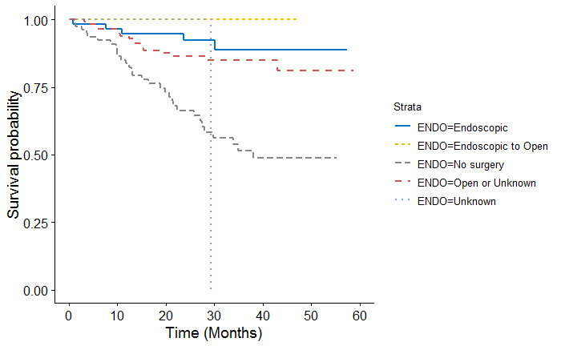